# main

```python
import pandas as pd
from ydata_profiling import ProfileReport
from sqlalchemy import create_engine
import os
import numpy as np
import seaborn as sns
import matplotlib.pyplot as plt

from sklearn.ensemble import IsolationForest
from sklearn.decomposition import PCA
from sklearn.preprocessing import StandardScaler
from sklearn.cluster import KMeans
from scipy.stats import chi2_contingency
```

First, let us set up a connect to the database using SQLAlchemy with create engine

```python
server = 'VALGRIND\SQLEXPRESS'
database = 'GoBest_Cab'
engine = create_engine(f"mssql+pyodbc://{server}/{database}?driver=SQL Server")
```

```python
connection = engine.connect()
cursor_cab = connection.execute('SELECT * FROM Cab_Driver')
cab_driver_df = pd.DataFrame(data = cursor_cab.fetchall(), columns= cursor_cab.keys())

cursor_safe = connection.execute('SELECT * FROM Safety_Labels')
safety_labels_df = pd.DataFrame(data = cursor_safe.fetchall(), columns= cursor_safe.keys())

cursor_sens = connection.execute('SELECT * FROM Sensor_Data')
sensor_data_df = pd.DataFrame(data = cursor_sens.fetchall(), columns= cursor_sens.keys())
connection.close()
```

#### Cab Driver

```python
cab_driver_df.head()
```

|  | driver_id | driver_name | data_of_birth | No_of_Years_driving_exp | gender | car_brand | car_model_year | driver_rating |
| --- | --- | --- | --- | --- | --- | --- | --- | --- |
| 0 | 1 | Sinclair Birmingham | 10/17/1982 | 10 | Male | Audi | 2010 | 3.8 |
| 1 | 2 | Juline Faulks | 11/30/1977 | 14 | Female | BMW | 2000 | 2.8 |
| 2 | 3 | Germayne Stit | 9/18/1976 | 13 | Male | Mercedes-Benz | 1999 | 3.8 |
| 3 | 4 | Athena Coudray | 10/24/1982 | 16 | Female | Lexus | 2009 | 2.2 |
| 4 | 5 | Batholomew Hiscoke | 9/11/1978 | 20 | Male | BMW | 2012 | 2.7 |

```python
display(cab_driver_df.info())
```

```
<class 'pandas.core.frame.DataFrame'>
RangeIndex: 500 entries, 0 to 499
Data columns (total 8 columns):
 #   Column                   Non-Null Count  Dtype
---  ------                   --------------  -----
 0   driver_id                500 non-null    int64
 1   driver_name              500 non-null    object
 2   data_of_birth            500 non-null    object
 3   No_of_Years_driving_exp  500 non-null    int64
 4   gender                   500 non-null    object
 5   car_brand                500 non-null    object
 6   car_model_year           500 non-null    object
 7   driver_rating            500 non-null    object
dtypes: int64(2), object(6)
memory usage: 31.4+ KB
```

```
None
```

```python
# Rename columns
cab_driver_df.rename(columns={'data_of_birth': 'date_of_birth', 'No_of_Years_driving_exp': 'num_of_years_driving_exp'}, inplace=True)
```

```python
# Change data type
convert_dict = {
    'driver_id': 'int16',
    'driver_name': str,
    'date_of_birth': 'datetime64',
    'num_of_years_driving_exp': 'int16',
    'gender': 'category',
    'car_brand': 'category',
    'car_model_year': 'int16',
    'driver_rating': 'float16'
}

cab_driver_df = cab_driver_df.astype(convert_dict)

display(cab_driver_df.info())
```

```
<class 'pandas.core.frame.DataFrame'>
RangeIndex: 500 entries, 0 to 499
Data columns (total 8 columns):
 #   Column                    Non-Null Count  Dtype
---  ------                    --------------  -----
 0   driver_id                 500 non-null    int16
 1   driver_name               500 non-null    object
 2   date_of_birth             500 non-null    datetime64[ns]
 3   num_of_years_driving_exp  500 non-null    int16
 4   gender                    500 non-null    category
 5   car_brand                 500 non-null    category
 6   car_model_year            500 non-null    int16
 7   driver_rating             500 non-null    float16
dtypes: category(2), datetime64[ns](1), float16(1), int16(3), object(1)
memory usage: 13.3+ KB
```

```
None
```

#### Safety Labels

```python
safety_labels_df.head()
```

|  | bookingID | driver_id | label |
| --- | --- | --- | --- |
| 0 | 0 | 359 | 0 |
| 1 | 1 | 313 | 1 |
| 2 | 2 | 27 | 1 |
| 3 | 4 | 164 | 1 |
| 4 | 6 | 118 | 0 |

```python
display(safety_labels_df.info())
```

```
<class 'pandas.core.frame.DataFrame'>
RangeIndex: 20000 entries, 0 to 19999
Data columns (total 3 columns):
 #   Column     Non-Null Count  Dtype
---  ------     --------------  -----
 0   bookingID  20000 non-null  int64
 1   driver_id  20000 non-null  int64
 2   label      20000 non-null  int64
dtypes: int64(3)
memory usage: 468.9 KB
```

```
None
```

```python
# Rename column
safety_labels_df.rename({'bookingID': 'booking_id'}, axis=1, inplace=True)
```

```python
# Change data type
convert_dict = {
    'booking_id': 'int64',
    'driver_id': 'int16',
    'label': 'int16'
}

safety_labels_df = safety_labels_df.astype(convert_dict)

display(safety_labels_df.info())
```

```
<class 'pandas.core.frame.DataFrame'>
RangeIndex: 20000 entries, 0 to 19999
Data columns (total 3 columns):
 #   Column      Non-Null Count  Dtype
---  ------      --------------  -----
 0   booking_id  20000 non-null  int64
 1   driver_id   20000 non-null  int16
 2   label       20000 non-null  int16
dtypes: int16(2), int64(1)
memory usage: 234.5 KB
```

```
None
```

#### Sensor Data

```python
sensor_data_df.head()
```

|  | Sensor_ID | bookingID | Accuracy | Bearing | acceleration_x | acceleration_y | acceleration_z | gyro_x | gyro_y | gyro_z | second | Speed |
| --- | --- | --- | --- | --- | --- | --- | --- | --- | --- | --- | --- | --- |
| 0 | 1 | 1202590843006 | 3.000 | 353.0 | 1.228867 | 8.900100 | 3.986968 | 0.008221 | 0.002269 | -0.009966 | 1362.0 | 0.000000 |
| 1 | 2 | 274877907034 | 9.293 | 17.0 | 0.032775 | 8.659933 | 4.737300 | 0.024629 | 0.004028 | -0.010858 | 257.0 | 0.190000 |
| 2 | 3 | 884763263056 | 3.000 | NaN | 1.139675 | 9.545974 | 1.951334 | -0.006899 | -0.015080 | 0.001122 | 973.0 | 0.667059 |
| 3 | 4 | 1073741824054 | 3.900 | 126.0 | 3.871543 | 10.386364 | -0.136474 | 0.001344 | -0.339601 | -0.017956 | 902.0 | 7.913285 |
| 4 | 5 | 1056561954943 | 3.900 | 50.0 | -0.112882 | 10.550960 | -1.560110 | 0.130568 | -0.061697 | 0.161530 | 820.0 | 20.419409 |

```python
display(sensor_data_df.info())
```

```
<class 'pandas.core.frame.DataFrame'>
RangeIndex: 7469656 entries, 0 to 7469655
Data columns (total 12 columns):
 #   Column          Dtype
---  ------          -----
 0   Sensor_ID       int64
 1   bookingID       int64
 2   Accuracy        float64
 3   Bearing         float64
 4   acceleration_x  float64
 5   acceleration_y  float64
 6   acceleration_z  float64
 7   gyro_x          float64
 8   gyro_y          float64
 9   gyro_z          float64
 10  second          float64
 11  Speed           float64
dtypes: float64(10), int64(2)
memory usage: 683.9 MB
```

```
None
```

```python
# Rename some columns
sensor_data_df.rename({'Sensor_ID': 'sensor_id', 'bookingID': 'booking_id', 'Accuracy': 'accuracy', 'Bearing': 'bearing', 'Speed': 'speed'}, axis=1, inplace=True)
```

```python
# Change data type
convert_dict = {
    'sensor_id': 'int32',
    'booking_id': 'int64',
    'accuracy': 'float32',
    'bearing': 'float32',
    'acceleration_x': 'float32',
    'acceleration_y': 'float32',
    'acceleration_z': 'float32',
    'gyro_x': 'float32',
    'gyro_y': 'float32',
    'gyro_z': 'float32',
    'second': 'float64',
    'speed': 'float32'
}

sensor_data_df = sensor_data_df.astype(convert_dict)

display(sensor_data_df.info())
```

```
<class 'pandas.core.frame.DataFrame'>
RangeIndex: 7469656 entries, 0 to 7469655
Data columns (total 12 columns):
 #   Column          Dtype
---  ------          -----
 0   sensor_id       int32
 1   booking_id      int64
 2   accuracy        float32
 3   bearing         float32
 4   acceleration_x  float32
 5   acceleration_y  float32
 6   acceleration_z  float32
 7   gyro_x          float32
 8   gyro_y          float32
 9   gyro_z          float32
 10  second          float64
 11  speed           float32
dtypes: float32(9), float64(1), int32(1), int64(1)
memory usage: 398.9 MB
```

```
None
```

#### Try merging the dataframes (sensor_data and safety_labels)

```python
# Merge dataframes sensor data and safety labels using booking_id
sensor_safety_df = pd.merge(sensor_data_df, safety_labels_df, on='booking_id', how='inner')
```

```python
sensor_safety_df.head()
```

|  | sensor_id | booking_id | accuracy | bearing | acceleration_x | acceleration_y | acceleration_z | gyro_x | gyro_y | gyro_z | second | speed | driver_id | label |
| --- | --- | --- | --- | --- | --- | --- | --- | --- | --- | --- | --- | --- | --- | --- |
| 0 | 1 | 1202590843006 | 3.000 | 353.0 | 1.228867 | 8.900100 | 3.986968 | 0.008221 | 0.002269 | -0.009966 | 1362.0 | 0.000000 | 349 | 1 |
| 1 | 36005 | 1202590843006 | 3.033 | 77.0 | 1.137217 | 8.975278 | 3.981050 | 0.021118 | -0.022515 | 0.024522 | 541.0 | 0.000000 | 349 | 1 |
| 2 | 37793 | 1202590843006 | 6.173 | 283.0 | 1.522818 | 7.947064 | 5.075056 | 0.137567 | -0.297055 | -0.017418 | 154.0 | 2.863286 | 349 | 1 |
| 3 | 57022 | 1202590843006 | 3.014 | 353.0 | 1.134775 | 8.932489 | 3.929421 | -0.007959 | -0.020543 | -0.022986 | 1384.0 | 0.000000 | 349 | 1 |
| 4 | 76232 | 1202590843006 | 5.209 | 340.0 | 0.858197 | NaN | 2.944571 | 0.061924 | 0.015219 | 0.025517 | 1142.0 | 9.750134 | 349 | 1 |

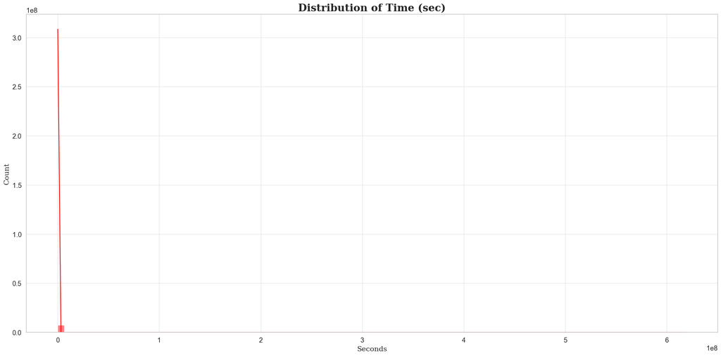

```python
seconds = sensor_safety_df['second'].to_numpy()

plt.figure(figsize=(20, 10))
sns.set_context('notebook',  font_scale=1.2)
sns.set_style('whitegrid', {'grid.color': '0.9'})

plt.xlabel('Seconds', fontsize=14, fontfamily='serif')
plt.ylabel('Count', fontsize=14, fontfamily='serif')

sns.histplot(seconds, bins=100, kde=True, color='red', alpha=0.5)

plt.title('Distribution of Time (sec)', fontsize=20, fontfamily='serif', fontweight='bold')
plt.tight_layout()
plt.show()
```

```python
display(sensor_safety_df['second'][sensor_safety_df['second'] > 6*(10**8)])
print(f"Number of extreme values {len(sensor_safety_df['second'][sensor_safety_df['second'] > 6*(10**8)])}")
```

```
210710     619315371.0
210713     619315480.0
210714     619315692.0
210726     619315826.0
210729     619315821.0
210732     619315786.0
210734     619315577.0
210738     619315608.0
210761     619315551.0
210762     619315764.0
210777     619315795.0
210782     619315801.0
210790     619315541.0
210802     619315702.0
210807     619315556.0
```

[output cut: 23 more lines]

```
Number of extreme values 37
```

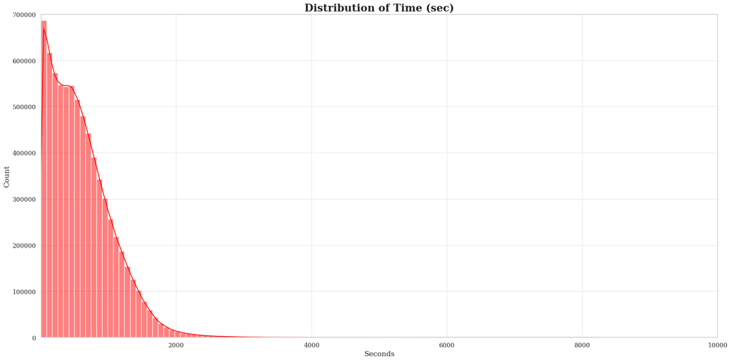

```python
sensor_safety_df['second'] = sensor_safety_df['second'][sensor_safety_df['second'] < 6*(10**8)]
seconds = sensor_safety_df['second'].to_numpy()


plt.figure(figsize=(20, 10))

sns.histplot(seconds, bins=100, kde=True, color='red', alpha=0.5)

plt.xlabel('Seconds', fontsize=14, fontfamily='serif')
plt.ylabel('Count', fontsize=14, fontfamily='serif')
plt.xticks([2000, 4000, 6000, 8000, 10000], fontsize=12, fontfamily='serif')
plt.yticks([0, 100_000, 200_000, 300_000, 400_000, 500_000, 600_000, 700_000], fontsize=12, fontfamily='serif')
plt.xlim(0, 10000)
plt.ylim(0, 700_000)


plt.title('Distribution of Time (sec)', fontsize=20, fontfamily='serif', fontweight='bold')
plt.tight_layout()
plt.show()
```

**Observations**

### Removal of extreme speed

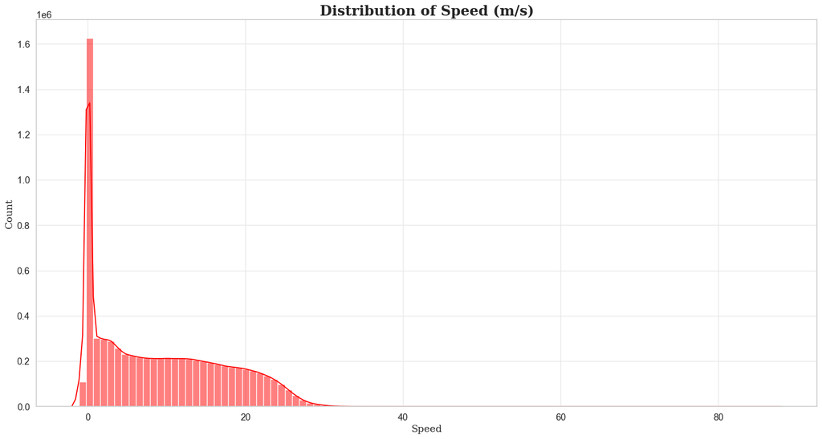

```python
seconds = sensor_safety_df['speed'].to_numpy()
fig = plt.figure(figsize=(20, 10))

sns.histplot(seconds, bins=100, kde=True, color='red', alpha=0.5)

plt.xlabel('Speed', fontsize=14, fontfamily='serif')
plt.ylabel('Count', fontsize=14, fontfamily='serif')

plt.title('Distribution of Speed (m/s)', fontsize=20, fontfamily='serif', fontweight='bold')

plt.show()
```

From the histogram, we can see that there are actually quite a few instances of having negative speed

We can first remove negative speed values as speed is scalar quantity with only magnitude and no direction

```python
# Show all those with speed -1
len(sensor_safety_df[sensor_safety_df['speed'] < 0])
```

```
109828
```

```python
# Removing negative values
sensor_safety_df = sensor_safety_df[sensor_safety_df['speed'] >= 0]
```

```python
display(sensor_safety_df['speed'].sort_values(ascending=False))
```

```
3700930    88.037254
3287551    50.549999
788882     44.969437
3287655    43.099998
3369179    42.807346
             ...
3334027     0.000000
3334030     0.000000
6319992     0.000000
3334033     0.000000
0           0.000000
Name: speed, Length: 7246879, dtype: float32
```

Although not visible from the histogram, we can also seem some extreme values of speed like 88m/s (which is actually around 300 km/h). Since it is quite hard to tell the value of speed when it is in m/s we will be changing its units to km/h. In addition, Singapore drivers also typically read speed as kilometers per hour

```python
# Convert from m/s to km/h
sensor_safety_df['speed'] = sensor_safety_df['speed'].apply(lambda x: x*3.6)
```

```python
display(sensor_safety_df['speed'].sort_values(ascending=False))
```

```
3700930    316.934116
3287551    181.979997
788882     161.889972
3287655    155.159995
3369179    154.106447
              ...
3334027      0.000000
3334030      0.000000
6319992      0.000000
3334033      0.000000
0            0.000000
Name: speed, Length: 7246879, dtype: float64
```

As seen here, it is physically impossible for a taxi to travel at 300km/h

```python
# Remove speed greater than 200 km/h
sensor_safety_df = sensor_safety_df[sensor_safety_df['speed'] <= 200]
```

### Check distribution of accuracy

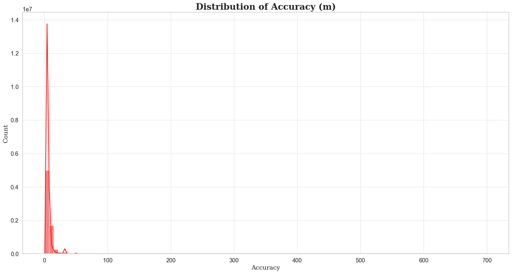

```python
# Plot histogram of accuracy
seconds = sensor_safety_df['accuracy'].to_numpy()
fig = plt.figure(figsize=(20, 10))

sns.histplot(seconds, bins=100, kde=True, color='red', alpha=0.5)

plt.xlabel('Accuracy', fontsize=14, fontfamily='serif')
plt.ylabel('Count', fontsize=14, fontfamily='serif')

plt.title('Distribution of Accuracy (m)', fontsize=20, fontfamily='serif', fontweight='bold')

plt.show()
```

**Observations**

### Check distribution of Bearing

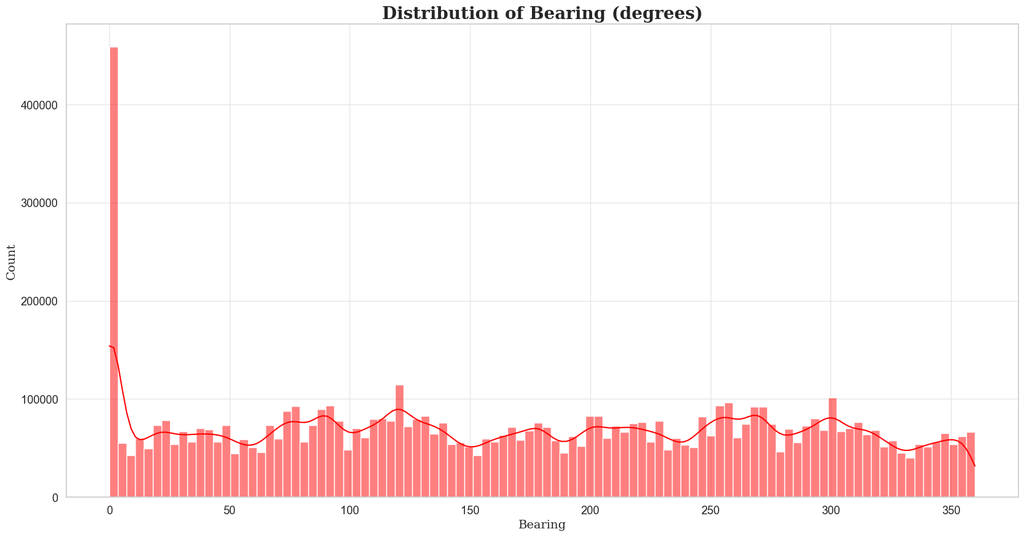

```python
# Plot histogram of bearing
seconds = sensor_safety_df['bearing'].to_numpy()
fig = plt.figure(figsize=(20, 10))

sns.histplot(seconds, bins=100, kde=True, color='red', alpha=0.5)

plt.xlabel('Bearing', fontsize=14, fontfamily='serif')
plt.ylabel('Count', fontsize=14, fontfamily='serif')

plt.title('Distribution of Bearing (degrees)', fontsize=20, fontfamily='serif', fontweight='bold')

plt.show()
```

**Observations**

- The bearing of GPS ranges from a range of many values with values of close to 0 being the most common which shows that most cabs detected were going in the north direction.

#### Data Cleaning

```python
cab_driver_df.isnull().sum()
```

```
driver_id                   0
driver_name                 0
date_of_birth               0
num_of_years_driving_exp    0
gender                      0
car_brand                   0
car_model_year              0
driver_rating               0
dtype: int64
```

```python
sensor_safety_df.isnull().sum()
```

```
sensor_id              0
booking_id             0
accuracy          139925
bearing           186427
acceleration_x    191470
acceleration_y    207982
acceleration_z     78170
gyro_x            154803
gyro_y            136115
gyro_z            166139
second            120192
speed                  0
driver_id              0
label                  0
dtype: int64
```

#### Check for extreme values first

```python
# Get all extreme values from sensor_safety_df

def calc_gates(series, gate_scale=1.5):
    Q1 = series.quantile(0.25)
    Q3 = series.quantile(0.75)
    IQR = Q3 - Q1
    lower_bound = Q1 - (gate_scale * IQR)
    upper_bound = Q3 + (gate_scale * IQR)
    return lower_bound, upper_bound

def get_extreme_values(df, column):
    lower_bound, upper_bound = calc_gates(df[column])
    return df[(df[column] < lower_bound) | (df[column] > upper_bound)]

for col in sensor_safety_df.columns:
    if sensor_safety_df[col].dtype != 'object':
        if len(get_extreme_values(sensor_safety_df, col)>0):
            print(f"Extreme values for {col}")
            display(get_extreme_values(sensor_safety_df, col).sort_values(by=col, ascending=False))
            print(f"25% of {col}")
            display(sensor_safety_df[col].quantile(0.25))
            print(f"75% of {col}")
            display(sensor_safety_df[col].quantile(0.75))
        else:
            print(f"No extreme values found for {col}")
        print('\n')
```

```
No extreme values found for sensor_id


No extreme values found for booking_id


Extreme values for accuracy
```

|  | sensor_id | booking_id | accuracy | bearing | acceleration_x | acceleration_y | acceleration_z | gyro_x | gyro_y | gyro_z | second | speed | driver_id | label |
| --- | --- | --- | --- | --- | --- | --- | --- | --- | --- | --- | --- | --- | --- | --- |
| 7442601 | 4866842 | 944892805233 | 699.999023 | 0.000000 | -2.018906 | 2.163162 | 9.598358 | 0.000168 | -0.019592 | 0.007675 | 363.0 | 0.000000 | 184 | 1 |
| 7442651 | 7165142 | 944892805233 | 500.000000 | 0.000000 | -8.995026 | 0.352554 | 1.696304 | 0.263672 | 0.070206 | -0.122757 | 433.0 | 0.000000 | 184 | 1 |
| 80130 | 2712655 | 1305670058125 | 426.135010 | 221.000000 | NaN | 9.379044 | 2.710358 | -0.000809 | 0.004501 | 0.000641 | 1209.0 | 33.875999 | 278 | 1 |
| 941364 | 1077532 | 1520418422849 | 400.000000 | 54.398830 | -5.190100 | 1.155765 | -5.419937 | 0.302186 | 0.082713 | 0.120910 | 1303.0 | 7.456569 | 272 | 1 |
| 78082 | 6960924 | 1262720385148 | 400.000000 | 353.573822 | -4.761679 | 5.894565 | -6.080887 | -0.330505 | 1.479222 | -1.054484 | 2730.0 | 0.000004 | 236 | 1 |
| ... | ... | ... | ... | ... | ... | ... | ... | ... | ... | ... | ... | ... | ... | ... |
| 821366 | 733170 | 936302870623 | 14.151000 | 215.000000 | -0.263290 | 7.439133 | 6.627075 | -0.043625 | -0.448425 | -0.478165 | 437.0 | 3.060000 | 447 | 1 |
| 6997785 | 6522546 | 609885356070 | 14.151000 | 343.000000 | -0.231639 | 9.633071 | 1.079186 | -0.005060 | -0.067112 | 0.018109 | 417.0 | 2.700000 | 145 | 0 |
| 6190486 | 1794203 | 292057776227 | 14.151000 | 0.000000 | -1.532135 | 5.219711 | 7.914398 | 0.847427 | -1.640793 | -0.727707 | 492.0 | 0.000000 | 225 | 1 |
| 772126 | 5443286 | 1357209665607 | 14.151000 | 229.000000 | -7.747780 | -5.896708 | 0.709680 | 0.012147 | 0.030543 | 0.010681 | 932.0 | 0.000000 | 7 | 1 |
| 3133144 | 6685501 | 635655159823 | 14.151000 | 169.000000 | 2.418546 | 9.243812 | -0.219366 | 0.016162 | 0.180362 | -0.215845 | 468.0 | 38.639791 | 303 | 0 |

421782 rows × 14 columns

```
25% of accuracy
```

```
3.9
```

```
75% of accuracy
```

```
8.0
```

```
No extreme values found for bearing


Extreme values for acceleration_x
```

|  | sensor_id | booking_id | accuracy | bearing | acceleration_x | acceleration_y | acceleration_z | gyro_x | gyro_y | gyro_z | second | speed | driver_id | label |
| --- | --- | --- | --- | --- | --- | --- | --- | --- | --- | --- | --- | --- | --- | --- |
| 365153 | 2006689 | 120259084337 | 32.000000 | 345.540070 | 66.873459 | -26.147289 | 8.354733 | 0.340852 | 0.786133 | 0.127790 | 1004.0 | 2.335434 | 300 | 1 |
| 7013122 | 1938967 | 798863917234 | 4.000000 | 348.000000 | 44.480839 | -57.800190 | 17.681719 | 0.435345 | 2.371385 | 0.154048 | 475.0 | 15.952028 | 398 | 0 |
| 4456303 | 6854010 | 1047972020273 | 27.188999 | 75.000000 | 43.942200 | 49.175266 | -8.445997 | NaN | 0.958116 | 4.814892 | 228.0 | 5.001007 | 90 | 1 |
| 4792599 | 6764543 | 1211180777486 | 3.000000 | 91.000000 | 35.868629 | -9.464568 | 20.341759 | -1.070861 | -0.684936 | 1.140626 | 77.0 | 18.761672 | 230 | 1 |
| 2459650 | 5013808 | 841813590145 | 8.000000 | 194.000000 | 34.080109 | 23.262774 | -1.836409 | 0.894020 | 0.171398 | 0.143035 | 871.0 | 42.343547 | 285 | 1 |
| ... | ... | ... | ... | ... | ... | ... | ... | ... | ... | ... | ... | ... | ... | ... |
| 1818841 | 1109196 | 893353197670 | 8.000000 | 173.000000 | -33.440838 | 3.636904 | -35.545403 | 0.367872 | 0.288493 | -0.070688 | 442.0 | 25.218793 | 317 | 0 |
| 3481154 | 4960682 | 1408749273160 | NaN | 202.000000 | -33.918533 | -31.497528 | 24.856735 | 1.747238 | 0.696899 | 0.849869 | 84.0 | 10.152000 | 432 | 1 |
| 5148974 | 6891203 | 506806141049 | 10.000000 | 351.379089 | -36.188194 | 11.942105 | 6.281714 | -7.707181 | -5.402968 | 3.767327 | 186.0 | 15.047999 | 16 | 1 |
| 3410997 | 4212900 | 489626271806 | 4.000000 | 210.000000 | -38.640579 | 28.872129 | -9.687696 | -0.589921 | -1.241348 | 1.142929 | 861.0 | 24.582268 | 213 | 1 |
| 654748 | 1930950 | 944892805224 | 3.125000 | 120.000000 | -38.983994 | -16.173233 | 30.856033 | 1.900345 | -1.115723 | 3.029678 | 1284.0 | 9.792000 | 270 | 1 |

444722 rows × 14 columns

```
25% of acceleration_x
```

```
-0.50758624
```

```
75% of acceleration_x
```

```
0.6344828
```

```
Extreme values for acceleration_y
```

|  | sensor_id | booking_id | accuracy | bearing | acceleration_x | acceleration_y | acceleration_z | gyro_x | gyro_y | gyro_z | second | speed | driver_id | label |
| --- | --- | --- | --- | --- | --- | --- | --- | --- | --- | --- | --- | --- | --- | --- |
| 1111214 | 1096786 | 403726925911 | 4.154 | 30.000000 | -7.525206 | 61.159355 | -63.560814 | -0.070990 | -1.017009 | 0.007849 | 115.0 | 9.694935 | 307 | 0 |
| 4199771 | 881685 | 42949673150 | 8.000 | 108.000000 | 12.400787 | 57.492294 | 35.649250 | -1.596732 | -0.538888 | 1.417993 | 947.0 | 50.103664 | 158 | 1 |
| 1110252 | 709682 | 1228360646749 | 6.000 | 49.000000 | 6.488698 | 56.736183 | 27.789968 | -0.984209 | -0.449876 | 0.381651 | 551.0 | 84.949338 | 347 | 0 |
| 4199859 | 2286912 | 42949673150 | 4.000 | 199.000000 | -6.834737 | 56.255695 | 22.120422 | 0.658827 | 0.298120 | 0.844146 | 507.0 | 73.632678 | 158 | 1 |
| 5947298 | 3544091 | 1254130450465 | 32.000 | 100.581657 | -13.971460 | 56.003525 | -16.310505 | -8.253393 | -3.377103 | 4.264934 | 309.0 | 3.427225 | 312 | 1 |
| ... | ... | ... | ... | ... | ... | ... | ... | ... | ... | ... | ... | ... | ... | ... |
| 5148469 | 3355520 | 506806141049 | 20.000 | 66.430534 | -0.145798 | -49.252266 | -30.262674 | -1.836378 | -1.422709 | -0.109728 | 982.0 | 8.100000 | 16 | 1 |
| 5148937 | 6629012 | 506806141049 | 10.000 | 290.795258 | -5.197876 | -50.476219 | 10.256833 | 7.486475 | 2.354474 | -1.945591 | 174.0 | 8.280000 | 16 | 1 |
| 1500724 | 994954 | 1623497637978 | 8.000 | 179.704468 | -3.547894 | -55.132179 | -11.971563 | -0.226715 | 1.189301 | -0.864217 | 2368.0 | 21.334397 | 462 | 1 |
| 3035998 | 784750 | 438086664329 | 6.000 | 220.108368 | -4.962805 | -57.303593 | -6.022867 | 2.608738 | 1.166983 | -0.852366 | 967.0 | 0.057803 | 335 | 1 |
| 7013122 | 1938967 | 798863917234 | 4.000 | 348.000000 | 44.480839 | -57.800190 | 17.681719 | 0.435345 | 2.371385 | 0.154048 | 475.0 | 15.952028 | 398 | 0 |

7216 rows × 14 columns

```
25% of acceleration_y
```

```
-0.6661835
```

```
75% of acceleration_y
```

```
9.7135725
```

```
Extreme values for acceleration_z
```

|  | sensor_id | booking_id | accuracy | bearing | acceleration_x | acceleration_y | acceleration_z | gyro_x | gyro_y | gyro_z | second | speed | driver_id | label |
| --- | --- | --- | --- | --- | --- | --- | --- | --- | --- | --- | --- | --- | --- | --- |
| 3585727 | 4155718 | 1305670058030 | 4.000 | 306.000000 | NaN | NaN | 78.055756 | -0.046194 | 0.042396 | -0.034896 | 214.0 | 18.320614 | 56 | 1 |
| 1987523 | 4145976 | 1606317768859 | 4.000 | 151.000000 | 7.173247 | -41.100121 | 77.665489 | -1.680249 | 0.426358 | 0.286157 | 82.0 | 73.053438 | 34 | 1 |
| 790832 | 969001 | 1606317768798 | 5.372 | 135.000000 | -3.215605 | 10.822443 | 73.314209 | -2.077256 | 0.485812 | -0.562258 | 939.0 | 7.536195 | 1 | 1 |
| 114601 | 1603779 | 506806141077 | 6.000 | 167.000000 | -5.592855 | -42.118797 | 72.889076 | -1.889650 | 0.160832 | -0.186488 | 345.0 | 21.795474 | 166 | 1 |
| 6331796 | 3361373 | 154618822732 | 6.000 | 13.000000 | 5.025583 | -11.954614 | 65.957481 | -1.545541 | -0.255415 | 0.026160 | 591.0 | 16.175327 | 401 | 1 |
| ... | ... | ... | ... | ... | ... | ... | ... | ... | ... | ... | ... | ... | ... | ... |
| 5053642 | 5806234 | 627065225318 | 32.000 | 164.003616 | 8.586365 | 21.871754 | -58.720745 | -0.572331 | -0.072964 | 0.050240 | 134.0 | 10.026607 | 442 | 1 |
| 1111570 | 5847134 | 403726925911 | 12.000 | 199.000000 | -14.068759 | 49.961334 | -59.516884 | 0.040798 | -0.067114 | -0.001925 | 913.0 | 92.748306 | 307 | 0 |
| 4825528 | 326586 | 1279900254364 | 4.000 | 245.000000 | 15.823586 | NaN | -59.957581 | -1.209251 | -0.264313 | 0.256022 | 97.0 | 41.217479 | 500 | 1 |
| 1111214 | 1096786 | 403726925911 | 4.154 | 30.000000 | -7.525206 | 61.159355 | -63.560814 | -0.070990 | -1.017009 | 0.007849 | 115.0 | 9.694935 | 307 | 0 |
| 4583888 | 824731 | 446676598913 | 3.818 | 103.000000 | -1.529942 | 7.786181 | -78.448418 | 1.461067 | -10.526457 | -0.806333 | 876.0 | 0.000000 | 140 | 0 |

271139 rows × 14 columns

```
25% of acceleration_z
```

```
-0.9026416
```

```
75% of acceleration_z
```

```
2.766568
```

```
Extreme values for gyro_x
```

|  | sensor_id | booking_id | accuracy | bearing | acceleration_x | acceleration_y | acceleration_z | gyro_x | gyro_y | gyro_z | second | speed | driver_id | label |
| --- | --- | --- | --- | --- | --- | --- | --- | --- | --- | --- | --- | --- | --- | --- |
| 207427 | 1776887 | 901943132262 | 14.291 | 0.0 | -10.738892 | -7.772995 | 9.174118 | 25.895302 | 2.049682 | -13.056065 | 33.0 | 0.000000 | 257 | 0 |
| 3541606 | 4769890 | 1125281431597 | 4.227 | 230.0 | 2.701148 | 34.080456 | 14.928882 | 18.309830 | -7.984427 | -5.909231 | 230.0 | 0.851126 | 134 | 0 |
| 2692986 | 2241383 | 240518168745 | 4.000 | 296.0 | -0.052674 | 9.330489 | -1.630501 | 14.840831 | -11.417146 | 6.290968 | 1262.0 | 75.109515 | 395 | 0 |
| 7113284 | 4966608 | 764504178767 | 20.000 | 211.0 | -9.921249 | -2.563217 | -2.725021 | 13.535559 | 5.273764 | 5.113445 | 130.0 | 17.532000 | 139 | 1 |
| 6907812 | 7387046 | 1288490188914 | 4.615 | 331.0 | -5.081665 | 1.462433 | 6.485260 | 12.927996 | -1.462821 | -37.465385 | 1319.0 | 4.716000 | 487 | 1 |
| ... | ... | ... | ... | ... | ... | ... | ... | ... | ... | ... | ... | ... | ... | ... |
| 1444609 | 1320526 | 352187318287 | 10.114 | 0.0 | 2.392227 | -2.140289 | 16.681732 | -20.690815 | 0.848940 | 3.506585 | 95.0 | 0.000000 | 451 | 0 |
| 3136474 | 4909612 | 1013612281892 | 10.720 | 311.0 | 0.130000 | 7.770000 | 7.640000 | -21.539999 | -26.619999 | -8.270000 | 586.0 | 60.839999 | 445 | 0 |
| 4658625 | 912317 | 1606317768837 | 5.826 | 0.0 | 16.256973 | -0.380005 | -5.161362 | -24.177795 | 20.268097 | -53.554451 | 318.0 | 0.000000 | 425 | 1 |
| 3285423 | 536148 | 1683627180111 | 4.000 | 207.0 | -0.957681 | 9.878476 | -1.395820 | -26.448021 | -26.729019 | 25.535389 | 1529.0 | 49.355135 | 175 | 1 |
| 4659084 | 4350270 | 1606317768837 | 5.812 | 0.0 | 9.509995 | -3.910400 | 4.488388 | -48.455750 | 9.905816 | -14.069954 | 321.0 | 0.000000 | 425 | 1 |

1093678 rows × 14 columns

```
25% of gyro_x
```

```
-0.026641846
```

```
75% of gyro_x
```

```
0.02321288
```

```
Extreme values for gyro_y
```

|  | sensor_id | booking_id | accuracy | bearing | acceleration_x | acceleration_y | acceleration_z | gyro_x | gyro_y | gyro_z | second | speed | driver_id | label |
| --- | --- | --- | --- | --- | --- | --- | --- | --- | --- | --- | --- | --- | --- | --- |
| 2332908 | 2787251 | 1400159338663 | 4.862 | 13.0 | 1.019287 | 10.284119 | 0.829880 | 4.932330 | 80.314964 | 7.089492 | 504.0 | 13.572000 | 431 | 1 |
| 2938199 | 402930 | 592705486925 | 3.900 | 249.0 | 0.154465 | 7.117188 | 5.874802 | 1.733265 | 62.542023 | 33.831825 | 971.0 | 15.947999 | 111 | 0 |
| 350856 | 5987541 | 214748364969 | 3.900 | 199.0 | 0.155075 | 9.351273 | 0.719559 | -0.029137 | 52.260242 | 0.559035 | 58.0 | 37.044000 | 184 | 0 |
| 7041859 | 1825781 | 1408749273111 | 3.900 | 61.0 | 0.297272 | 9.109772 | 1.460571 | 5.035828 | 48.495224 | 7.510161 | 577.0 | 42.192001 | 119 | 0 |
| 1139031 | 6976484 | 1511828488241 | 3.900 | 26.0 | -0.102356 | 10.800201 | 1.182312 | -2.960908 | 40.342510 | 5.412510 | 956.0 | 43.775999 | 366 | 0 |
| ... | ... | ... | ... | ... | ... | ... | ... | ... | ... | ... | ... | ... | ... | ... |
| 3966153 | 3307736 | 790273982602 | 7.767 | 330.0 | 0.415573 | 5.589798 | 3.962494 | -9.454512 | -33.878094 | -28.180916 | 197.0 | 9.360000 | 26 | 1 |
| 4764086 | 2282962 | 1176821039124 | 3.900 | 236.0 | -0.474396 | 9.294876 | 1.149826 | 1.050537 | -34.954002 | -2.739527 | 193.0 | 30.456000 | 264 | 0 |
| 2487570 | 6746512 | 1675037245591 | 3.900 | 258.0 | 0.064987 | 9.552307 | 6.448486 | 0.798910 | -36.997116 | -21.691290 | 830.0 | 96.624001 | 239 | 0 |
| 5916449 | 3776886 | 369367187610 | 3.900 | NaN | -0.204102 | 9.766830 | -1.032761 | -4.581866 | -55.157585 | 5.108685 | 197.0 | 79.524001 | 99 | 0 |
| 626390 | 1528103 | 1133871366294 | NaN | 0.0 | 0.169785 | 6.492004 | 7.077942 | 9.696174 | -57.344891 | 2.599002 | 449.0 | 0.000000 | 372 | 1 |

1151870 rows × 14 columns

```
25% of gyro_y
```

```
-0.029827405
```

```
75% of gyro_y
```

```
0.031215824
```

```
Extreme values for gyro_z
```

|  | sensor_id | booking_id | accuracy | bearing | acceleration_x | acceleration_y | acceleration_z | gyro_x | gyro_y | gyro_z | second | speed | driver_id | label |
| --- | --- | --- | --- | --- | --- | --- | --- | --- | --- | --- | --- | --- | --- | --- |
| 2415249 | 7332546 | 1417339207787 | 9.000 | 38.0 | -3.035767 | 5.087204 | 7.181534 | 2.695508 | -5.810982 | 45.059864 | 281.0 | 30.600000 | 263 | 0 |
| 2938199 | 402930 | 592705486925 | 3.900 | 249.0 | 0.154465 | 7.117188 | 5.874802 | 1.733265 | 62.542023 | 33.831825 | 971.0 | 15.947999 | 111 | 0 |
| 4704542 | 6334379 | 884763263050 | 3.900 | 287.0 | 2.326019 | 0.810898 | 8.556915 | 6.146956 | 0.046946 | 33.379864 | 1491.0 | 61.812000 | 158 | 0 |
| 3285423 | 536148 | 1683627180111 | 4.000 | 207.0 | -0.957681 | 9.878476 | -1.395820 | -26.448021 | -26.729019 | 25.535389 | 1529.0 | 49.355135 | 175 | 1 |
| 4230012 | 5955828 | 103079215179 | 8.000 | 61.0 | 1.396835 | 1.105698 | 9.809708 | -3.772640 | 12.229509 | 21.247093 | 358.0 | 18.575999 | 305 | 1 |
| ... | ... | ... | ... | ... | ... | ... | ... | ... | ... | ... | ... | ... | ... | ... |
| 4229742 | 434214 | 103079215179 | 6.447 | 0.0 | -0.897919 | 7.715393 | 6.848099 | -1.811138 | NaN | -24.401278 | 390.0 | 0.000000 | 305 | 1 |
| 3966153 | 3307736 | 790273982602 | 7.767 | 330.0 | 0.415573 | 5.589798 | 3.962494 | -9.454512 | -33.878094 | -28.180916 | 197.0 | 9.360000 | 26 | 1 |
| 6143609 | 7256684 | 1099511627813 | 3.900 | 216.0 | 0.700577 | 5.765091 | 8.323395 | -2.970735 | -20.761961 | -29.735018 | 714.0 | 52.704001 | 102 | 1 |
| 6907812 | 7387046 | 1288490188914 | 4.615 | 331.0 | -5.081665 | 1.462433 | 6.485260 | 12.927996 | -1.462821 | -37.465385 | 1319.0 | 4.716000 | 487 | 1 |
| 4658625 | 912317 | 1606317768837 | 5.826 | 0.0 | 16.256973 | -0.380005 | -5.161362 | -24.177795 | 20.268097 | -53.554451 | 318.0 | 0.000000 | 425 | 1 |

1002703 rows × 14 columns

```
25% of gyro_z
```

```
-0.018615723
```

```
75% of gyro_z
```

```
0.018177517
```

```
Extreme values for second
```

|  | sensor_id | booking_id | accuracy | bearing | acceleration_x | acceleration_y | acceleration_z | gyro_x | gyro_y | gyro_z | second | speed | driver_id | label |
| --- | --- | --- | --- | --- | --- | --- | --- | --- | --- | --- | --- | --- | --- | --- |
| 978564 | 4948885 | 438086664371 | 3.748 | 0.000000 | -2.766500 | 3.031059 | 8.805874 | -0.039319 | -0.031358 | 0.011871 | 8234.0 | 0.000000 | 349 | 1 |
| 977420 | 2456529 | 438086664371 | 3.771 | 0.000000 | -3.208230 | 3.236961 | 8.626308 | 0.010161 | -0.098553 | 0.022256 | 8233.0 | 0.000000 | 349 | 1 |
| 976848 | 1201564 | 438086664371 | 3.803 | 0.000000 | -3.435679 | NaN | 8.544906 | 0.047424 | 0.019955 | 0.038138 | 8232.0 | 0.000000 | 349 | 1 |
| 976958 | 1451612 | 438086664371 | 3.913 | 0.000000 | 4.181473 | 1.329979 | 5.712565 | 0.379734 | -1.140689 | 0.312417 | 8230.0 | 0.000000 | 349 | 1 |
| 978839 | 5545024 | 438086664371 | 4.152 | 0.000000 | -2.712631 | NaN | 8.741230 | -0.637967 | -0.485231 | 0.035695 | 8228.0 | 0.000000 | 349 | 1 |
| ... | ... | ... | ... | ... | ... | ... | ... | ... | ... | ... | ... | ... | ... | ... |
| 3779507 | 7134285 | 283467841670 | 3.000 | 131.276993 | -0.485394 | -8.398099 | -1.463211 | -0.088438 | -0.055562 | 0.012945 | 1792.0 | 55.822326 | 410 | 1 |
| 1423475 | 4307555 | 1571958030348 | 11.792 | 39.000000 | 0.881393 | 10.275131 | -0.785278 | 0.002731 | -0.167236 | 0.018600 | 1792.0 | 25.560000 | 118 | 0 |
| 878568 | 3640688 | 1202590842948 | 4.000 | 24.000000 | -1.040367 | 9.855090 | -0.844387 | 0.051924 | 0.081053 | -0.025011 | 1792.0 | 44.977880 | 115 | 1 |
| 2573852 | 2616560 | 1563368095775 | 3.000 | 28.000000 | -0.524346 | 10.020041 | -0.098165 | -0.019630 | -0.033698 | 0.022566 | 1792.0 | 2.634858 | 115 | 0 |
| 2188275 | 4652411 | 1606317768842 | 4.000 | 131.000000 | -0.746991 | 8.489840 | 6.033388 | 0.105680 | -0.043371 | 0.014661 | 1792.0 | 63.575999 | 455 | 1 |

107581 rows × 14 columns

```
25% of second
```

```
241.0
```

```
75% of second
```

```
861.0
```

```
Extreme values for speed
```

|  | sensor_id | booking_id | accuracy | bearing | acceleration_x | acceleration_y | acceleration_z | gyro_x | gyro_y | gyro_z | second | speed | driver_id | label |
| --- | --- | --- | --- | --- | --- | --- | --- | --- | --- | --- | --- | --- | --- | --- |
| 3287551 | 1411482 | 738734374968 | 22.511999 | 247.000000 | -2.307648 | 9.837494 | 1.906754 | -0.242294 | 0.635406 | -0.332550 | 639.0 | 181.979997 | 451 | 1 |
| 788882 | 1189252 | 566935683204 | 32.000000 | 160.000000 | -0.775745 | 10.156514 | 2.032739 | 0.000678 | -0.105945 | 0.097181 | 1066.0 | 161.889972 | 101 | 0 |
| 3287655 | 2311800 | 738734374968 | 16.079000 | 259.000000 | -2.880722 | 9.339188 | 2.087402 | -0.227478 | NaN | -0.360519 | 641.0 | 155.159995 | 451 | 1 |
| 3369179 | 5817395 | 1365799600188 | 8.000000 | 120.000000 | 1.264704 | 4.223879 | 8.592081 | 0.010507 | 0.033563 | -0.016703 | 337.0 | 154.106447 | 183 | 1 |
| 5845552 | 127390 | 996432412737 | 12.000000 | 0.000000 | -0.383072 | 8.350976 | 5.516241 | 0.017942 | -0.030351 | 0.006981 | 732.0 | 153.026656 | 327 | 0 |
| ... | ... | ... | ... | ... | ... | ... | ... | ... | ... | ... | ... | ... | ... | ... |
| 2854411 | 3220732 | 661424963591 | 4.000000 | 249.631256 | 1.207504 | -8.701358 | 0.162247 | -0.127478 | 0.026327 | -0.237279 | 841.0 | 134.005408 | 369 | 0 |
| 6955902 | 5615872 | 377957122122 | 6.000000 | 346.826233 | -0.637473 | -12.177176 | 1.598840 | -0.059878 | 0.147166 | 0.572974 | 1269.0 | 133.759122 | 15 | 0 |
| 6955924 | 6147483 | 377957122122 | 6.000000 | 346.826233 | -0.413617 | -11.543741 | 0.364719 | 0.169166 | 0.293973 | NaN | 1268.0 | 133.759122 | 15 | 0 |
| 2854260 | 1659839 | 661424963591 | 5.000000 | 272.858734 | 1.184625 | -9.035721 | -0.129498 | -0.059128 | -0.068262 | 0.124198 | 1114.0 | 133.693945 | 369 | 0 |
| 2854701 | 6512670 | 661424963591 | 5.000000 | 276.220337 | 0.893030 | -9.713867 | -2.179639 | 0.059922 | 0.152074 | -0.011968 | 1115.0 | 133.693945 | 369 | 0 |

79 rows × 14 columns

```
25% of speed
```

```
4.535999965667725
```

```
75% of speed
```

```
56.16168794631958
```

```
No extreme values found for driver_id


No extreme values found for label
```

```python
# Group sensor_safety_df by booking_id (unique key)
sensor_safety_grouped = sensor_safety_df.groupby('booking_id')
display(sensor_safety_grouped.head())
```

|  | sensor_id | booking_id | accuracy | bearing | acceleration_x | acceleration_y | acceleration_z | gyro_x | gyro_y | gyro_z | second | speed | driver_id | label |
| --- | --- | --- | --- | --- | --- | --- | --- | --- | --- | --- | --- | --- | --- | --- |
| 0 | 1 | 1202590843006 | 3.000 | 353.000000 | 1.228867 | 8.900100 | 3.986968 | 0.008221 | 0.002269 | -0.009966 | 1362.0 | 0.000000 | 349 | 1 |
| 1 | 36005 | 1202590843006 | 3.033 | 77.000000 | 1.137217 | 8.975278 | 3.981050 | 0.021118 | -0.022515 | 0.024522 | 541.0 | 0.000000 | 349 | 1 |
| 2 | 37793 | 1202590843006 | 6.173 | 283.000000 | 1.522818 | 7.947064 | 5.075056 | 0.137567 | -0.297055 | -0.017418 | 154.0 | 10.307830 | 349 | 1 |
| 3 | 57022 | 1202590843006 | 3.014 | 353.000000 | 1.134775 | 8.932489 | 3.929421 | -0.007959 | -0.020543 | -0.022986 | 1384.0 | 0.000000 | 349 | 1 |
| 4 | 76232 | 1202590843006 | 5.209 | 340.000000 | 0.858197 | NaN | 2.944571 | 0.061924 | 0.015219 | 0.025517 | 1142.0 | 35.100484 | 349 | 1 |
| ... | ... | ... | ... | ... | ... | ... | ... | ... | ... | ... | ... | ... | ... | ... |
| 7469612 | 1331301 | 317827579936 | NaN | 107.233719 | 0.050262 | -1.019745 | -0.105118 | -0.008879 | -0.026914 | 0.027343 | 1.0 | 22.646642 | 224 | 1 |
| 7469613 | 1396805 | 317827579936 | 8.000 | 47.093388 | 0.383896 | -1.118851 | -0.078064 | -0.012207 | -0.053673 | 0.241194 | 471.0 | 83.334629 | 224 | 1 |
| 7469614 | 1487590 | 317827579936 | 8.000 | 49.320091 | 0.014923 | -0.911423 | -0.453918 | 0.117212 | -0.078938 | 0.080113 | 509.0 | 46.341880 | 224 | 1 |
| 7469615 | 1510787 | 317827579936 | 8.000 | 47.526382 | -0.099838 | -1.147659 | -0.219040 | 0.146051 | 0.169827 | -0.066196 | 529.0 | 47.384136 | 224 | 1 |
| 7469616 | 1691565 | 317827579936 | 12.000 | 46.056789 | 0.096878 | -1.055557 | 0.191910 | -0.002958 | 0.015130 | -0.019046 | 517.0 | 18.237262 | 224 | 1 |

99857 rows × 14 columns

```python
# Drop rows of data that has null values from second
sensor_safety_df.dropna(subset=['second'], inplace=True)
print(sensor_safety_df.isnull().sum())
```

```
sensor_id              0
booking_id             0
accuracy          136625
bearing           183545
acceleration_x    187869
acceleration_y    204169
acceleration_z     76585
gyro_x            152299
gyro_y            133640
gyro_z            162868
second                 0
speed                  0
driver_id              0
label                  0
dtype: int64
```

```python
# Sort back by sensor_id and booking_id
sensor_safety_df.sort_values(by=['sensor_id', 'booking_id'], inplace=True)
sensor_safety_df.head()
```

|  | sensor_id | booking_id | accuracy | bearing | acceleration_x | acceleration_y | acceleration_z | gyro_x | gyro_y | gyro_z | second | speed | driver_id | label |
| --- | --- | --- | --- | --- | --- | --- | --- | --- | --- | --- | --- | --- | --- | --- |
| 0 | 1 | 1202590843006 | 3.000 | 353.0 | 1.228867 | 8.900100 | 3.986968 | 0.008221 | 0.002269 | -0.009966 | 1362.0 | 0.000000 | 349 | 1 |
| 528 | 2 | 274877907034 | 9.293 | 17.0 | 0.032775 | 8.659933 | 4.737300 | 0.024629 | 0.004028 | -0.010858 | 257.0 | 0.684000 | 412 | 1 |
| 1261 | 3 | 884763263056 | 3.000 | NaN | 1.139675 | 9.545974 | 1.951334 | -0.006899 | -0.015080 | 0.001122 | 973.0 | 2.401412 | 348 | 1 |
| 2081 | 4 | 1073741824054 | 3.900 | 126.0 | 3.871542 | 10.386364 | -0.136474 | 0.001344 | -0.339601 | -0.017956 | 902.0 | 28.487827 | 206 | 0 |
| 2543 | 5 | 1056561954943 | 3.900 | 50.0 | -0.112882 | 10.550960 | -1.560110 | 0.130568 | -0.061697 | 0.161530 | 820.0 | 73.509872 | 390 | 1 |

```python
# Check interpolate column value
display(sensor_safety_df)
```

|  | sensor_id | booking_id | accuracy | bearing | acceleration_x | acceleration_y | acceleration_z | gyro_x | gyro_y | gyro_z | second | speed | driver_id | label |
| --- | --- | --- | --- | --- | --- | --- | --- | --- | --- | --- | --- | --- | --- | --- |
| 0 | 1 | 1202590843006 | 3.000 | 353.000000 | 1.228867 | 8.900100 | 3.986968 | 0.008221 | 0.002269 | -0.009966 | 1362.0 | 0.000000 | 349 | 1 |
| 528 | 2 | 274877907034 | 9.293 | 17.000000 | 0.032775 | 8.659933 | 4.737300 | 0.024629 | 0.004028 | -0.010858 | 257.0 | 0.684000 | 412 | 1 |
| 1261 | 3 | 884763263056 | 3.000 | NaN | 1.139675 | 9.545974 | 1.951334 | -0.006899 | -0.015080 | 0.001122 | 973.0 | 2.401412 | 348 | 1 |
| 2081 | 4 | 1073741824054 | 3.900 | 126.000000 | 3.871542 | 10.386364 | -0.136474 | 0.001344 | -0.339601 | -0.017956 | 902.0 | 28.487827 | 206 | 0 |
| 2543 | 5 | 1056561954943 | 3.900 | 50.000000 | -0.112882 | 10.550960 | -1.560110 | 0.130568 | -0.061697 | 0.161530 | 820.0 | 73.509872 | 390 | 1 |
| ... | ... | ... | ... | ... | ... | ... | ... | ... | ... | ... | ... | ... | ... | ... |
| 2311486 | 7469652 | 884763262985 | 3.900 | 226.000000 | 0.260422 | 9.907822 | 3.162796 | 0.013733 | 0.010056 | 0.017792 | 98.0 | 35.927998 | 429 | 0 |
| 4332239 | 7469653 | 1571958030347 | 5.000 | 341.782990 | -1.168625 | -9.396103 | -0.009271 | 0.032545 | 0.009954 | 0.038534 | 509.0 | 23.184000 | 57 | 0 |
| 5282940 | 7469654 | 584115552361 | 6.000 | 50.000000 | 6.186806 | 6.809318 | 0.234639 | 0.505468 | 0.255951 | 0.202501 | 519.0 | 32.325406 | 143 | 1 |
| 2121019 | 7469655 | 1073741824126 | 10.720 | 324.000000 | -0.274582 | 8.512177 | 3.903046 | -0.037451 | -0.044601 | -0.033173 | 2289.0 | 31.572002 | 356 | 1 |
| 2908056 | 7469656 | 884763263001 | 12.000 | 357.002563 | 0.989182 | -9.599024 | -6.042905 | 0.035069 | -0.031591 | 0.021383 | 310.0 | 101.513267 | 16 | 0 |

7126686 rows × 14 columns

```python
sensor_safety_df.isnull().sum()
```

```
sensor_id              0
booking_id             0
accuracy          136625
bearing           183545
acceleration_x    187869
acceleration_y    204169
acceleration_z     76585
gyro_x            152299
gyro_y            133640
gyro_z            162868
second                 0
speed                  0
driver_id              0
label                  0
dtype: int64
```

#### Removal of extreme values

```python
cab_driver_df.describe()
```

|  | driver_id | num_of_years_driving_exp | car_model_year | driver_rating |
| --- | --- | --- | --- | --- |
| count | 500.000000 | 500.00000 | 500.000000 | 500.000000 |
| mean | 250.500000 | 14.91400 | 2000.652000 | 3.550781 |
| std | 144.481833 | 6.03452 | 8.728762 | 0.853027 |
| min | 1.000000 | 5.00000 | 1953.000000 | 2.000000 |
| 25% | 125.750000 | 9.75000 | 1995.000000 | 2.800781 |
| 50% | 250.500000 | 15.00000 | 2002.000000 | 3.599609 |
| 75% | 375.250000 | 20.00000 | 2008.000000 | 4.300781 |
| max | 500.000000 | 25.00000 | 2013.000000 | 5.000000 |

```python
# Describe the data without standard notation
with pd.option_context('display.float_format', '{:.3f}'.format):
    display(sensor_safety_df.describe())
```

|  | sensor_id | booking_id | accuracy | bearing | acceleration_x | acceleration_y | acceleration_z | gyro_x | gyro_y | gyro_z | second | speed | driver_id | label |
| --- | --- | --- | --- | --- | --- | --- | --- | --- | --- | --- | --- | --- | --- | --- |
| count | 7126686.000 | 7126686.000 | 6990061.000 | 6943141.000 | 6938817.000 | 6922517.000 | 7050101.000 | 6974387.000 | 6993046.000 | 6963818.000 | 7126686.000 | 7126686.000 | 7126686.000 | 7126686.000 |
| mean | 3728842.321 | 818283360615.710 | 6.715 | 169.687 | 0.069 | 4.563 | 0.925 | -0.002 | 0.000 | -0.000 | 600.534 | 32.960 | 250.061 | 0.303 |
| std | 2155895.620 | 495185120860.546 | 7.448 | 106.976 | 1.407 | 8.089 | 3.221 | 0.139 | 0.336 | 0.142 | 461.205 | 29.059 | 144.598 | 0.460 |
| min | 1.000 | 0.000 | 0.750 | 0.000 | -38.984 | -57.800 | -78.448 | -48.456 | -57.345 | -53.554 | 0.000 | 0.000 | 1.000 | 0.000 |
| 25% | 1862310.250 | 377957122219.000 | 3.900 | 79.000 | -0.508 | -0.680 | -0.903 | -0.027 | -0.030 | -0.019 | 241.000 | 4.536 | 124.000 | 0.000 |
| 50% | 3722595.500 | 807453851663.000 | 4.027 | 169.000 | 0.062 | 9.098 | 0.796 | -0.001 | 0.000 | -0.000 | 519.000 | 27.936 | 250.000 | 0.000 |
| 75% | 5594330.750 | 1254130450440.000 | 8.000 | 263.000 | 0.634 | 9.714 | 2.766 | 0.023 | 0.031 | 0.018 | 861.000 | 56.160 | 374.000 | 1.000 |
| max | 7469656.000 | 1709396983975.000 | 699.999 | 359.999 | 66.873 | 61.159 | 78.056 | 25.895 | 80.315 | 45.060 | 8234.000 | 181.980 | 500.000 | 1.000 |

**Observations**:

```python
display(sensor_safety_df.sort_values(by='second', ascending=False))
```

|  | sensor_id | booking_id | accuracy | bearing | acceleration_x | acceleration_y | acceleration_z | gyro_x | gyro_y | gyro_z | second | speed | driver_id | label |
| --- | --- | --- | --- | --- | --- | --- | --- | --- | --- | --- | --- | --- | --- | --- |
| 978564 | 4948885 | 438086664371 | 3.748 | 0.000000 | -2.766500 | 3.031059 | 8.805874 | -0.039319 | -0.031358 | 0.011871 | 8234.0 | 0.000000 | 349 | 1 |
| 977420 | 2456529 | 438086664371 | 3.771 | 0.000000 | -3.208230 | 3.236961 | 8.626308 | 0.010161 | -0.098553 | 0.022256 | 8233.0 | 0.000000 | 349 | 1 |
| 976848 | 1201564 | 438086664371 | 3.803 | 0.000000 | -3.435679 | NaN | 8.544906 | 0.047424 | 0.019955 | 0.038138 | 8232.0 | 0.000000 | 349 | 1 |
| 976958 | 1451612 | 438086664371 | 3.913 | 0.000000 | 4.181473 | 1.329979 | 5.712565 | 0.379734 | -1.140689 | 0.312417 | 8230.0 | 0.000000 | 349 | 1 |
| 978839 | 5545024 | 438086664371 | 4.152 | 0.000000 | -2.712631 | NaN | 8.741230 | -0.637967 | -0.485231 | 0.035695 | 8228.0 | 0.000000 | 349 | 1 |
| ... | ... | ... | ... | ... | ... | ... | ... | ... | ... | ... | ... | ... | ... | ... |
| 129692 | 6141362 | 472446402670 | 6.000 | 44.000000 | -0.183865 | 9.228191 | -1.025111 | 0.098803 | 0.028135 | 0.055135 | 0.0 | 54.988845 | 358 | 0 |
| 5907769 | 6141364 | 1365799600266 | 3.900 | 218.000000 | -0.095768 | 9.299079 | 0.260968 | 0.034954 | -0.001552 | -0.068930 | 0.0 | 42.659998 | 291 | 0 |
| 2238341 | 241611 | 25769803867 | 4.011 | 32.000000 | 0.329682 | NaN | 0.449593 | -0.003770 | -0.002513 | 0.000401 | 0.0 | 0.000000 | 42 | 0 |
| 6927431 | 629211 | 962072674392 | 3.000 | NaN | -0.402238 | 10.084685 | 2.025557 | -0.030398 | -0.001367 | -0.017889 | 0.0 | 5.941008 | 415 | 0 |
| 4910221 | 5667991 | 60129542239 | 6.000 | 52.449028 | -0.501993 | -9.704297 | 1.245337 | -0.008908 | -0.021392 | 0.027552 | 0.0 | 0.562754 | 170 | 0 |

7126686 rows × 14 columns

```python
print("Before interpolation")
print(sensor_safety_df.isnull().sum())

# Sort by seconds
sensor_safety_df.sort_values(by=['second'], inplace=True)

# Interpolate missing values
sensor_safety_df.interpolate(method='linear', inplace=True)
print()
print("After interpolation")
print(sensor_safety_df.isnull().sum())
```

```
Before interpolation
sensor_id              0
booking_id             0
accuracy          136625
bearing           183545
acceleration_x    187869
acceleration_y    204169
acceleration_z     76585
gyro_x            152299
gyro_y            133640
gyro_z            162868
second                 0
speed                  0
driver_id              0
label                  0
dtype: int64

After interpolation
sensor_id         0
booking_id        0
accuracy          0
bearing           0
acceleration_x    0
acceleration_y    0
acceleration_z    0
gyro_x            0
gyro_y            0
gyro_z            0
second            0
speed             0
driver_id         0
label             0
dtype: int64
```

Check for infinity values after interpolation

```python
# Check for inf values in any of the columns
display(sensor_safety_df[sensor_safety_df[sensor_safety_df.columns] == np.inf].sum())
```

```
sensor_id         0.0
booking_id        0.0
accuracy          0.0
bearing           0.0
acceleration_x    0.0
acceleration_y    0.0
acceleration_z    0.0
gyro_x            0.0
gyro_y            0.0
gyro_z            0.0
second            0.0
speed             0.0
driver_id         0.0
label             0.0
dtype: float64
```

```python
display(sensor_safety_df['speed'].sort_values(ascending=False))
```

```
3287551    181.979997
788882     161.889972
3287655    155.159995
3369179    154.106447
5845552    153.026656
              ...
6994138      0.000000
6495836      0.000000
5234018      0.000000
1206780      0.000000
978564       0.000000
Name: speed, Length: 7126686, dtype: float64
```

## Feature Engineering

- Engineer more features for data analysis.

### Acceleration Magnitude

- Measure of the absolute change in speed or force, regardless of direction of the movement. $$ \sqrt{\text{acc\_x}^2 + \text{acc\_y}^2 + \text{acc\_z}^2 } $$

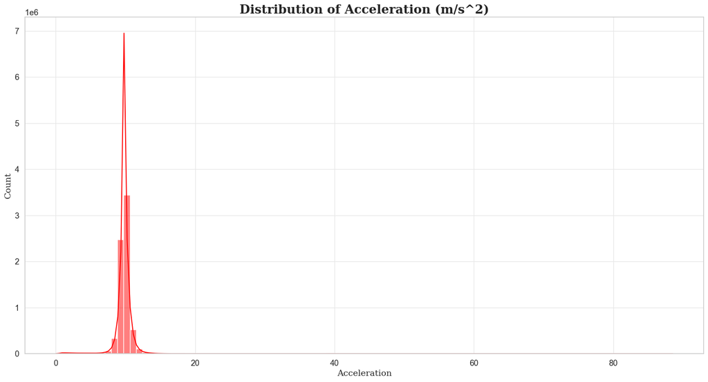

```python
# Calculate magnitude of acceleration
acc_mag = ((sensor_safety_df['acceleration_x']**2 + sensor_safety_df['acceleration_y']**2 + sensor_safety_df['acceleration_z']**2)**0.5).sort_values(ascending=False)

# Plot histogram
plt.figure(figsize=(20, 10))

sns.histplot(acc_mag, bins=100, kde=True, color='red', alpha=0.5)

plt.xlabel('Acceleration', fontsize=14, fontfamily='serif')
plt.ylabel('Count', fontsize=14, fontfamily='serif')

plt.title('Distribution of Acceleration (m/s^2)', fontsize=20, fontfamily='serif', fontweight='bold')

plt.show()
```

```python
sensor_safety_df['acceleration_magnitude'] = acc_mag[acc_mag < 70]
```

### Gyro Magnitude

- Rate of directional change between successive orientations meaurements in rad/s $$ \sqrt{\text{gyro\_x}^2 + \text{gyro\_y}^2 + \text{gyro\_z}^2 } $$

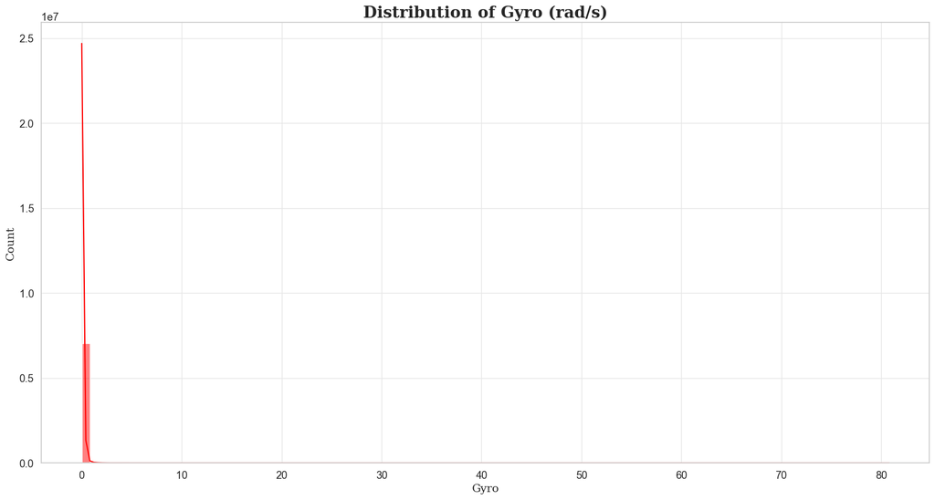

```python
# Calculate magnitude of gyro
gyro_mag = ((sensor_safety_df['gyro_x']**2 + sensor_safety_df['gyro_y']**2 + sensor_safety_df['gyro_z']**2)**0.5).sort_values(ascending=False)

# Plot histogram
plt.figure(figsize=(20, 10))

sns.histplot(gyro_mag, bins=100, kde=True, color='red', alpha=0.5)

plt.xlabel('Gyro', fontsize=14, fontfamily='serif')
plt.ylabel('Count', fontsize=14, fontfamily='serif')

plt.title('Distribution of Gyro (rad/s)', fontsize=20, fontfamily='serif', fontweight='bold')

plt.show()
```

A gyroscope reading of 70 radians per second is extremely high and would be beyond the typical range of gyroscope readings for automotive applications. The values of 70 radians per second would correspond to a very high and unrealistic rate of rotation

```python
sensor_safety_df['gyro_magnitude'] = gyro_mag[gyro_mag < 70]
```

### Age of Drivers

- Current age of the driver
- Calculated using date of birth $$ \text{Age} = \text{Current Year} - \text{Date of Birth} $$

```python
#Convert the data type of 'date_of_birth' to datetime
cab_driver_df['date_of_birth'] = pd.to_datetime(cab_driver_df['date_of_birth'])

# Find age of drivers
cab_driver_df['date_of_birth'] = pd.to_datetime(cab_driver_df['date_of_birth'])
cur_year = pd.to_datetime('today').year
cab_driver_df['driver_age'] = cur_year - cab_driver_df['date_of_birth'].dt.year

display(cab_driver_df.head())
```

|  | driver_id | driver_name | date_of_birth | num_of_years_driving_exp | gender | car_brand | car_model_year | driver_rating | driver_age |
| --- | --- | --- | --- | --- | --- | --- | --- | --- | --- |
| 0 | 1 | Sinclair Birmingham | 1982-10-17 | 10 | Male | Audi | 2010 | 3.800781 | 41 |
| 1 | 2 | Juline Faulks | 1977-11-30 | 14 | Female | BMW | 2000 | 2.800781 | 46 |
| 2 | 3 | Germayne Stit | 1976-09-18 | 13 | Male | Mercedes-Benz | 1999 | 3.800781 | 47 |
| 3 | 4 | Athena Coudray | 1982-10-24 | 16 | Female | Lexus | 2009 | 2.199219 | 41 |
| 4 | 5 | Batholomew Hiscoke | 1978-09-11 | 20 | Male | BMW | 2012 | 2.699219 | 45 |

### Age of Manufacture

- Obtain the car manufacture age
- Calculate age of car using the car's manufactured date

$$ \text{Manufacture Age} = \text{Current Year} - \text{Car Model Year} $$

```python
# Find age of cars from when they were manufactured
cab_driver_df['car_age'] = cur_year - cab_driver_df['car_model_year']
display(cab_driver_df.head())
```

|  | driver_id | driver_name | date_of_birth | num_of_years_driving_exp | gender | car_brand | car_model_year | driver_rating | driver_age | car_age |
| --- | --- | --- | --- | --- | --- | --- | --- | --- | --- | --- |
| 0 | 1 | Sinclair Birmingham | 1982-10-17 | 10 | Male | Audi | 2010 | 3.800781 | 41 | 13 |
| 1 | 2 | Juline Faulks | 1977-11-30 | 14 | Female | BMW | 2000 | 2.800781 | 46 | 23 |
| 2 | 3 | Germayne Stit | 1976-09-18 | 13 | Male | Mercedes-Benz | 1999 | 3.800781 | 47 | 24 |
| 3 | 4 | Athena Coudray | 1982-10-24 | 16 | Female | Lexus | 2009 | 2.199219 | 41 | 14 |
| 4 | 5 | Batholomew Hiscoke | 1978-09-11 | 20 | Male | BMW | 2012 | 2.699219 | 45 | 11 |

[figure not shown]

*Figure: Image explaining Pitch Roll Yaw*

#### Pitch

- Rotation about the transverse axis (side-to-side tilt)
- Measured in radians
- Calculated by: $$ \theta = tan^{-1}\left(\frac{acc_{y}}{\sqrt{{acc_{x}}^{2} + {acc_{z}}^{2}}}\right) $$

```python
# Formulate the column for pitch
pitch = np.arctan2(
    sensor_safety_df["acceleration_y"],
    np.sqrt(sensor_safety_df["acceleration_x"]**2 + sensor_safety_df["acceleration_z"]**2)
    )
display(pitch)

# Find lowest value of pitch
print(f"Lowest value of pitch: {pitch.min()}")
# Find highest value of pitch
print(f"Highest value of pitch: {pitch.max()}")
```

```
6774039   -1.349175
3402069    1.286224
473706    -0.097897
2724933   -1.473695
6935789    1.473952
             ...
978839     0.031446
976958     0.185701
976848     0.243040
977420     0.338194
978564     0.317290
Length: 7126686, dtype: float32
```

```
Lowest value of pitch: -1.5706077814102173
Highest value of pitch: 1.5707963705062866
```

```python
# Add to dataframe
sensor_safety_df["pitch"] = pitch
display(sensor_safety_df.head())
```

|  | sensor_id | booking_id | accuracy | bearing | acceleration_x | acceleration_y | acceleration_z | gyro_x | gyro_y | gyro_z | second | speed | driver_id | label | acceleration_magnitude | gyro_magnitude | pitch |
| --- | --- | --- | --- | --- | --- | --- | --- | --- | --- | --- | --- | --- | --- | --- | --- | --- | --- |
| 6774039 | 2687037 | 1348619731067 | 4.000 | 2.846444 | -1.168475 | -9.913498 | -1.903744 | 0.071355 | 0.120739 | 0.028943 | 0.0 | 35.178078 | 442 | 0 | 10.162038 | 0.143203 | -1.349175 |
| 3402069 | 7027663 | 1305670058088 | 4.551 | 179.000000 | 1.767822 | 9.211441 | 2.033432 | 0.090790 | -0.000916 | -0.016373 | 0.0 | 48.456000 | 57 | 0 | 9.597431 | 0.092259 | 1.286224 |
| 473706 | 2133302 | 8589934600 | 3.209 | 330.000000 | 1.168370 | -0.259213 | 2.366668 | -0.003665 | -0.004887 | 0.010996 | 0.0 | 8.493149 | 456 | 1 | 2.652056 | 0.012578 | -0.097897 |
| 2724933 | 4657992 | 498216206436 | 16.000 | 260.999878 | 0.316568 | -9.729868 | 0.893329 | -0.014891 | 0.006484 | 0.002129 | 0.0 | 9.377673 | 394 | 0 | 9.775918 | 0.016380 | -1.473695 |
| 6935789 | 5613431 | 25769803861 | 3.856 | 69.000000 | -0.108000 | 9.392000 | -0.906000 | 0.007401 | -0.015167 | 0.024612 | 0.0 | 9.144555 | 75 | 1 | 9.436216 | 0.029843 | 1.473952 |

#### Roll

- Rotation around the longitudinal axis (front-to-back tilt)
- Measured in radians
- Calculated by: $$ \phi = tan^{-1}\left(\frac{acc_{x}}{\sqrt{{acc_{y}}^{2} + {acc_{z}}^{2}}}\right) $$

```python
# Formulate the column for roll
roll = np.arctan2(
    sensor_safety_df["acceleration_x"],
    np.sqrt(sensor_safety_df["acceleration_y"]**2 + sensor_safety_df["acceleration_z"]**2)
    )
display(roll)

# Find lowest value of roll
print(f"Lowest value of roll: {roll.min()}")
# Find highest value of roll
print(f"Highest value of roll: {roll.max()}")
```

```
6774039   -0.115239
3402069    0.185255
473706     0.456214
2724933    0.032388
6935789   -0.011446
             ...
978839    -0.300750
976958     0.619339
976848    -0.370504
977420    -0.335074
978564    -0.288757
Length: 7126686, dtype: float32
```

```
Lowest value of roll: -1.5690895318984985
Highest value of roll: 1.5702719688415527
```

```python
# Add to dataframe
sensor_safety_df["roll"] = roll
display(sensor_safety_df.head())
```

|  | sensor_id | booking_id | accuracy | bearing | acceleration_x | acceleration_y | acceleration_z | gyro_x | gyro_y | gyro_z | second | speed | driver_id | label | acceleration_magnitude | gyro_magnitude | pitch | roll |
| --- | --- | --- | --- | --- | --- | --- | --- | --- | --- | --- | --- | --- | --- | --- | --- | --- | --- | --- |
| 6774039 | 2687037 | 1348619731067 | 4.000 | 2.846444 | -1.168475 | -9.913498 | -1.903744 | 0.071355 | 0.120739 | 0.028943 | 0.0 | 35.178078 | 442 | 0 | 10.162038 | 0.143203 | -1.349175 | -0.115239 |
| 3402069 | 7027663 | 1305670058088 | 4.551 | 179.000000 | 1.767822 | 9.211441 | 2.033432 | 0.090790 | -0.000916 | -0.016373 | 0.0 | 48.456000 | 57 | 0 | 9.597431 | 0.092259 | 1.286224 | 0.185255 |
| 473706 | 2133302 | 8589934600 | 3.209 | 330.000000 | 1.168370 | -0.259213 | 2.366668 | -0.003665 | -0.004887 | 0.010996 | 0.0 | 8.493149 | 456 | 1 | 2.652056 | 0.012578 | -0.097897 | 0.456214 |
| 2724933 | 4657992 | 498216206436 | 16.000 | 260.999878 | 0.316568 | -9.729868 | 0.893329 | -0.014891 | 0.006484 | 0.002129 | 0.0 | 9.377673 | 394 | 0 | 9.775918 | 0.016380 | -1.473695 | 0.032388 |
| 6935789 | 5613431 | 25769803861 | 3.856 | 69.000000 | -0.108000 | 9.392000 | -0.906000 | 0.007401 | -0.015167 | 0.024612 | 0.0 | 9.144555 | 75 | 1 | 9.436216 | 0.029843 | 1.473952 | -0.011446 |

#### Yaw

- Rotation around the vertical axis (Heading or compass direction)
- Measured in radians
- Calculated by: $$ \psi = tan^{-1}\left(\frac{acc_{z}}{\sqrt{{acc_{x}}^{2} + {acc_{y}}^{2}}}\right) $$

```python
# Formulate the column for yaw
yaw = np.arctan2(
    sensor_safety_df["acceleration_z"],
    np.sqrt(sensor_safety_df["acceleration_x"]**2 + sensor_safety_df["acceleration_y"]**2)
    )
display(yaw)

# Find lowest value of yaw
print(f"Lowest value of yaw: {yaw.min()}")
# Find highest value of yaw
print(f"Highest value of yaw: {yaw.max()}")
```

```
6774039   -0.188452
3402069    0.213491
473706     1.102614
2724933    0.091508
6935789   -0.096161
             ...
978839     1.268304
976958     0.915804
976848     1.121020
977420     1.084747
978564     1.134696
Length: 7126686, dtype: float32
```

```
Lowest value of yaw: -1.5702934265136719
Highest value of yaw: 1.5706716775894165
```

```python
# Add to dataframe
sensor_safety_df["yaw"] = yaw
display(sensor_safety_df.head())
```

|  | sensor_id | booking_id | accuracy | bearing | acceleration_x | acceleration_y | acceleration_z | gyro_x | gyro_y | gyro_z | second | speed | driver_id | label | acceleration_magnitude | gyro_magnitude | pitch | roll | yaw |
| --- | --- | --- | --- | --- | --- | --- | --- | --- | --- | --- | --- | --- | --- | --- | --- | --- | --- | --- | --- |
| 6774039 | 2687037 | 1348619731067 | 4.000 | 2.846444 | -1.168475 | -9.913498 | -1.903744 | 0.071355 | 0.120739 | 0.028943 | 0.0 | 35.178078 | 442 | 0 | 10.162038 | 0.143203 | -1.349175 | -0.115239 | -0.188452 |
| 3402069 | 7027663 | 1305670058088 | 4.551 | 179.000000 | 1.767822 | 9.211441 | 2.033432 | 0.090790 | -0.000916 | -0.016373 | 0.0 | 48.456000 | 57 | 0 | 9.597431 | 0.092259 | 1.286224 | 0.185255 | 0.213491 |
| 473706 | 2133302 | 8589934600 | 3.209 | 330.000000 | 1.168370 | -0.259213 | 2.366668 | -0.003665 | -0.004887 | 0.010996 | 0.0 | 8.493149 | 456 | 1 | 2.652056 | 0.012578 | -0.097897 | 0.456214 | 1.102614 |
| 2724933 | 4657992 | 498216206436 | 16.000 | 260.999878 | 0.316568 | -9.729868 | 0.893329 | -0.014891 | 0.006484 | 0.002129 | 0.0 | 9.377673 | 394 | 0 | 9.775918 | 0.016380 | -1.473695 | 0.032388 | 0.091508 |
| 6935789 | 5613431 | 25769803861 | 3.856 | 69.000000 | -0.108000 | 9.392000 | -0.906000 | 0.007401 | -0.015167 | 0.024612 | 0.0 | 9.144555 | 75 | 1 | 9.436216 | 0.029843 | 1.473952 | -0.011446 | -0.096161 |

#### Duration

- Total duration of a trip
- Calculated by taking $\max (seconds) $ grouped by booking ID
- Assumes that each trip starts from 0 seconds (since trips cannot just start halfway)

```python
# Group sensor_safety_df by booking_id (unique key)
sensor_safety_grouped = sensor_safety_df.groupby('booking_id')

# Get the max seconds - min seconds
time_diff = sensor_safety_grouped['second'].max()

display(time_diff)
```

```
booking_id
0                1589.0
1                1034.0
2                 822.0
4                1092.0
6                1092.0
                  ...
1709396983957    1044.0
1709396983960     809.0
1709396983966     988.0
1709396983971    1076.0
1709396983975     556.0
Name: second, Length: 19972, dtype: float64
```

Check all trips less than 1 minute 30 seconds

```python
display(time_diff[time_diff < 90])
```

```
booking_id
85899345985      43.0
893353197629     49.0
1357209665672    14.0
Name: second, dtype: float64
```

```python
# Add time_diff to sensor_safety_df
sensor_safety_df['duration'] = sensor_safety_df['booking_id'].map(time_diff)
display(sensor_safety_df.head())
```

|  | sensor_id | booking_id | accuracy | bearing | acceleration_x | acceleration_y | acceleration_z | gyro_x | gyro_y | gyro_z | second | speed | driver_id | label | acceleration_magnitude | gyro_magnitude | pitch | roll | yaw | duration |
| --- | --- | --- | --- | --- | --- | --- | --- | --- | --- | --- | --- | --- | --- | --- | --- | --- | --- | --- | --- | --- |
| 6774039 | 2687037 | 1348619731067 | 4.000 | 2.846444 | -1.168475 | -9.913498 | -1.903744 | 0.071355 | 0.120739 | 0.028943 | 0.0 | 35.178078 | 442 | 0 | 10.162038 | 0.143203 | -1.349175 | -0.115239 | -0.188452 | 282.0 |
| 3402069 | 7027663 | 1305670058088 | 4.551 | 179.000000 | 1.767822 | 9.211441 | 2.033432 | 0.090790 | -0.000916 | -0.016373 | 0.0 | 48.456000 | 57 | 0 | 9.597431 | 0.092259 | 1.286224 | 0.185255 | 0.213491 | 1333.0 |
| 473706 | 2133302 | 8589934600 | 3.209 | 330.000000 | 1.168370 | -0.259213 | 2.366668 | -0.003665 | -0.004887 | 0.010996 | 0.0 | 8.493149 | 456 | 1 | 2.652056 | 0.012578 | -0.097897 | 0.456214 | 1.102614 | 1886.0 |
| 2724933 | 4657992 | 498216206436 | 16.000 | 260.999878 | 0.316568 | -9.729868 | 0.893329 | -0.014891 | 0.006484 | 0.002129 | 0.0 | 9.377673 | 394 | 0 | 9.775918 | 0.016380 | -1.473695 | 0.032388 | 0.091508 | 611.0 |
| 6935789 | 5613431 | 25769803861 | 3.856 | 69.000000 | -0.108000 | 9.392000 | -0.906000 | 0.007401 | -0.015167 | 0.024612 | 0.0 | 9.144555 | 75 | 1 | 9.436216 | 0.029843 | 1.473952 | -0.011446 | -0.096161 | 883.0 |

Although, these trips are very short, we won't remove them since they may provide some interesting findings

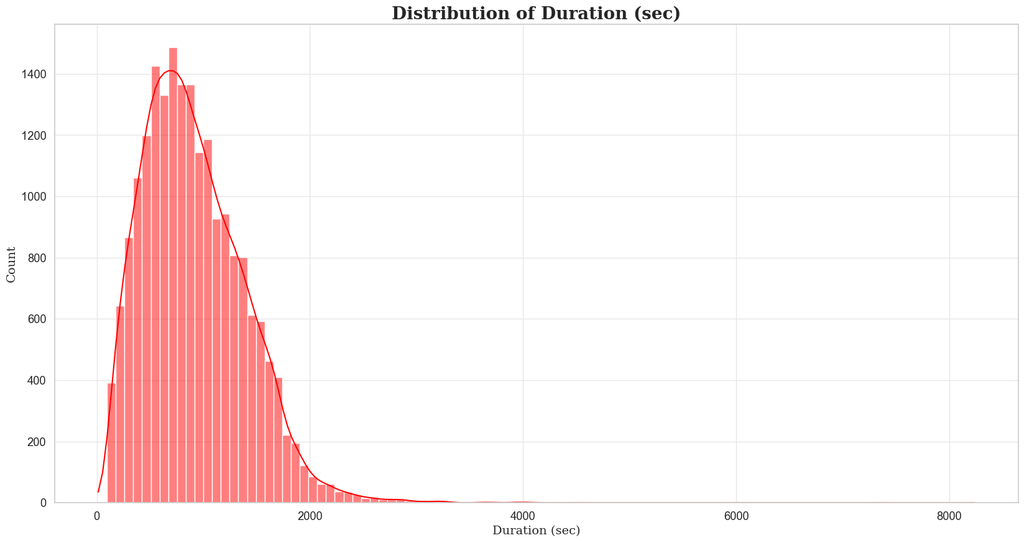

```python
# Plot a histogram of duration
plt.figure(figsize=(20, 10))

sns.histplot(time_diff, bins=100, kde=True, color='red', alpha=0.5)

plt.xlabel('Duration (sec)', fontsize=14, fontfamily='serif')
plt.ylabel('Count', fontsize=14, fontfamily='serif')

plt.title('Distribution of Duration (sec)', fontsize=20, fontfamily='serif', fontweight='bold')

plt.show()
```

**Observations**

### Distance

- Obtain the distance of the entire trip

```python
# Calculate the distance travelled
sensor_safety_df['distance'] = sensor_safety_df['speed'] * (sensor_safety_df['duration']/3600)
```

#### Write the data to csv file

Used by the Tableau Team

```python
dir =  os.path.join(os.getcwd(), 'tableauDatasets')

if not os.path.exists(dir):
    os.makedirs(dir)
else:
    for file in os.listdir(dir): os.remove(os.path.join(dir, file))

cab_driver_df.to_csv(os.path.join(dir, 'cab_driver.csv'), chunksize=10_000, index=False)
sensor_safety_df.to_csv(os.path.join(dir, 'sensor_safety.csv'), chunksize=10_000, index=False)
```

#### Write the data into a hdf5 file for faster load time

Used by the EDA Team

```python
dir =  os.path.join(os.getcwd(), 'pipelineDatasets')

if not os.path.exists(dir):
    os.makedirs(dir)
else:
    for file in os.listdir(dir): os.remove(os.path.join(dir, file))

cab_driver_df.to_hdf(f"{dir}/cab_driver.h5", key='cab_driver', mode='w', format='t')
sensor_safety_df.to_hdf(f"{dir}/sensor_safety.h5", key='safety_labels', mode='w', format='t')
```

### EDA

```python
# Read from hdf5 file
cab_driver_df = pd.read_hdf(f"pipelineDatasets/cab_driver.h5", key='cab_driver', chunksize=10_000)
sensor_safety_df = pd.read_hdf(f"pipelineDatasets/sensor_safety.h5", key='safety_labels', chunksize=10_000)

# Combine all chunks into one dataframe
cab_driver_df = pd.concat(cab_driver_df)
sensor_safety_df = pd.concat(sensor_safety_df)
```

```python
print("STATISTICS FOR CAB DRIVER")
cab_driver_df.info()

print()

print("STATISTICS FOR SENSOR SAFETY")
sensor_safety_df.info(show_counts=True)
```

```
STATISTICS FOR CAB DRIVER
<class 'pandas.core.frame.DataFrame'>
Int64Index: 500 entries, 0 to 499
Data columns (total 10 columns):
 #   Column                    Non-Null Count  Dtype
---  ------                    --------------  -----
 0   driver_id                 500 non-null    int16
 1   driver_name               500 non-null    object
 2   date_of_birth             500 non-null    datetime64[ns]
 3   num_of_years_driving_exp  500 non-null    int16
 4   gender                    500 non-null    category
 5   car_brand                 500 non-null    category
 6   car_model_year            500 non-null    int16
 7   driver_rating             500 non-null    float16
 8   driver_age                500 non-null    int64
 9   car_age                   500 non-null    int16
dtypes: category(2), datetime64[ns](1), float16(1), int16(4), int64(1), object(1)
memory usage: 22.0+ KB

STATISTICS FOR SENSOR SAFETY
<class 'pandas.core.frame.DataFrame'>
Int64Index: 7126686 entries, 6774039 to 978564
Data columns (total 21 columns):
 #   Column                  Non-Null Count    Dtype
---  ------                  --------------    -----
 0   sensor_id               7126686 non-null  int32
 1   booking_id              7126686 non-null  int64
 2   accuracy                7126686 non-null  float32
 3   bearing                 7126686 non-null  float32
 4   acceleration_x          7126686 non-null  float32
 5   acceleration_y          7126686 non-null  float32
 6   acceleration_z          7126686 non-null  float32
 7   gyro_x                  7126686 non-null  float32
 8   gyro_y                  7126686 non-null  float32
 9   gyro_z                  7126686 non-null  float32
 10  second                  7126686 non-null  float64
 11  speed                   7126686 non-null  float64
 12  driver_id               7126686 non-null  int16
 13  label                   7126686 non-null  int16
 14  acceleration_magnitude  7126677 non-null  float64
 15  gyro_magnitude          7126684 non-null  float64
 16  pitch                   7126686 non-null  float32
 17  roll                    7126686 non-null  float32
 18  yaw                     7126686 non-null  float32
 19  duration                7126686 non-null  float64
 20  distance                7126686 non-null  float64
dtypes: float32(11), float64(6), int16(2), int32(1), int64(1)
memory usage: 788.4 MB
```

**Observations**:

```python
# Describe the data without standard notation
with pd.option_context('display.float_format', '{:.3f}'.format):
    display(cab_driver_df.describe())
```

|  | driver_id | num_of_years_driving_exp | car_model_year | driver_rating | driver_age | car_age |
| --- | --- | --- | --- | --- | --- | --- |
| count | 500.000 | 500.000 | 500.000 | 500.000 | 500.000 | 500.000 |
| mean | 250.500 | 14.914 | 2000.652 | 3.551 | 47.028 | 22.348 |
| std | 144.482 | 6.035 | 8.729 | 0.853 | 3.665 | 8.729 |
| min | 1.000 | 5.000 | 1953.000 | 2.000 | 41.000 | 10.000 |
| 25% | 125.750 | 9.750 | 1995.000 | 2.801 | 44.000 | 15.000 |
| 50% | 250.500 | 15.000 | 2002.000 | 3.600 | 47.000 | 21.000 |
| 75% | 375.250 | 20.000 | 2008.000 | 4.301 | 50.000 | 28.000 |
| max | 500.000 | 25.000 | 2013.000 | 5.000 | 53.000 | 70.000 |

**Observations**:

```python
# Print list of columns
print(list(cab_driver_df.columns))
```

```
['driver_id', 'driver_name', 'date_of_birth', 'num_of_years_driving_exp', 'gender', 'car_brand', 'car_model_year', 'driver_rating', 'driver_age', 'car_age']
```

```python
# Get all categorical columns
categorical_col = cab_driver_df.select_dtypes(include=['category', 'object'])

#prints unique categorical values
for cat_val in categorical_col.columns:
    print(f'{cat_val} - {cab_driver_df[cat_val].unique()}')
```

```
driver_name - ['Sinclair Birmingham' 'Juline Faulks' 'Germayne Stit' 'Athena Coudray'
 'Batholomew Hiscoke' 'Keely Vidineev' 'Aeriela Hamly' 'Lew Painter'
 'Anatole Anstee' 'Garrek Maddra' 'Gwenni Corssen' 'Persis Slipper'
 'Eustacia Zannuto' 'Care Huortic' 'Nealson Andries' 'Brinna Andrewartha'
 'Reina Grigoriev' 'Dulcinea Hann' 'Sheffield Kivits' 'Barbe Berendsen'
 'Layney Eskrigge' 'Dominic Rydzynski' 'Reidar Hunnam' 'Arie Wingeat'
 'Royall Cochet' 'Carlie Bilverstone' 'Euell Jepperson' 'Kacie Danev'
 'Ervin Lawranson' 'Giuseppe Chellam' 'Barde Attrey' 'Isidor Whisker'
 'Rosana Kalisz' 'Terri-jo Ingarfield' 'Rosalinda Grabert'
 'Fredericka Keelan' 'Zelma Outibridge' 'Alane Draycott'
 'Dorothee Halbeard' 'Chas McCathie' 'Bernelle Eadmeades'
 'Wilmette Graveney' 'Jacquetta Camelin' 'Gaile Wagg' 'Othella Charnock'
 'Becky Allabush' 'Lynsey Haggerwood' 'Kelvin Kinkaid' 'Harald Byram'
 'Antonina Coghill' 'Ellsworth Scardefield' 'Alejoa Ahmad'
 'Fonzie Fitzroy' 'Dela Almak' 'Alysa Jore' 'Irma Minet' 'Julietta Ormrod'
 'Silvano MacCathay' 'Romonda Sommerland' 'Elbert Rummings'
 'Evangelina Tumber' 'Nancie Gribbon' 'Robbie Russan' 'Vale Castrillo'
 'Washington Pallent' 'Yardley Bowditch' 'Grange Shelmardine'
 'Wilbur Balfre' 'Benton Dickie' 'Alina Treagus' 'Alfred Auchterlony'
 'Wallis Ledingham' 'Nessy Barbera' 'Matthew Thripp' 'Benni Bagge'
 'Delora Yellop' 'Courtnay Ridgwell' 'Rosabelle Maddocks' 'Morten Grundon'
 'Erskine Absolon' 'Avrom Klousner' 'Heywood Barabisch' 'Adi Westgate'
 'Juliane Brimm' 'Vergil Richten' 'Dorice Wattingham' 'Correy Gillebert'
 'Galina Clow' 'Renee Hyman' 'Ranique Hance' 'Charlton Klimke'
 'Eveline Wallworth' 'Lauritz Brignell' 'Boony Keat' 'Kurtis Cuerdale'
 'Arturo Nordass' 'Marrissa Coase' 'Amabelle Baines' 'Rayshell Bloggett'
 'Lenee Hugk' 'Alwyn Ceyssen' 'Essa Philpott' 'Anson Constance'
 'Manya Folbige' 'Chiarra Fassam' 'Maud Hoyle' 'Gaston Nock'
 'Merry Jeannaud' 'Richie Aldrich' 'Gabriel Robbs' 'Chick Fearey'
 'Nikolia Shilito' 'Meredith Bowfin' 'Kessia Ely' 'Mei Stead'
 'Imojean Girkins' 'Odette Woodley' 'Ronny Hugill' 'Giulia Woodroof'
 'Jessee Mayne' 'Shalom Anshell' 'Carlos Thowes' 'Editha Hedingham'
 'Marcel Gissing' 'Lanni McGeneay' 'Hussein Calderhead' 'Ferguson Ellin'
 'Quintina Dollar' 'Blakeley Skerratt' 'Kettie Oswick' 'Ewart Mattiuzzi'
 'Damien Jakel' 'Malchy Nuschke' 'Mead Perrett' 'Duff Dennert'
 'Jordanna Keepe' 'Mordecai Loos' 'Hestia Gianulli' 'Viv Hatterslay'
 'Nance Gatherer' 'Bird Platfoot' 'Bari Exer' 'Tanhya Jarritt'
 'Janos Carhart' 'Nyssa Westrip' 'Ricca Klement' 'Briant Chaize'
 'Wolf Maseyk' 'Niall Gumary' 'Letitia Haverson' 'Dominique Bapty'
 'Timotheus Terzza' 'Sula Greenroyd' 'Hinda Dunston' 'Howie Bengefield'
```

[output cut: 78 more lines]

```
 'Cybil Garbutt' 'Gennie Blunsom' 'Land Geane' 'Godfree Follacaro'
 'Zulema Briskey' 'Carmela Gaspard' 'Dian Dubois' 'Ced Benaine'
 'Johnny Ticksall' 'Daniel Vernay' 'Debera Tredget' 'Salvidor Gelly'
 'Hazlett Sterndale' 'Gerry Hundell' 'Tore Ismay' 'Sarita Mapples'
 'Nellie Tomasino' 'Valera Greenall' 'Timmie Sauniere' 'Gwennie Mellody'
 "Pamella O'Mailey" 'Caril Seawright' 'Deidre Sussems' 'Derek Claire'
 'Ramona Cornewell' 'Coop Castanone' 'Burr Northill' 'Adelheid Doddrell'
 'Jenilee Wyldes' 'Brinna Pordall' 'Ynez Wincom' 'Yanaton Cottell'
 'Ashli Blesli' 'Ellwood Burgott' 'Mariquilla Tilmouth' 'Analiese Acedo'
 'Gale Bewfield' 'Shalom Okroy' 'Farleigh Aughtie']
gender - ['Male', 'Female']
Categories (2, object): ['Female', 'Male']
car_brand - ['Audi', 'BMW', 'Mercedes-Benz', 'Lexus', 'Nissan', ..., 'Volkswagen', 'Hyundai', 'Honda', 'Kia', 'Mazda']
Length: 12
Categories (12, object): ['Audi', 'BMW', 'Honda', 'Hyundai', ..., 'Mitsubishi', 'Nissan', 'Toyota', 'Volkswagen']
```

```python
# Describe the data without standard notation
with pd.option_context('display.float_format', '{:.3f}'.format):
    display(sensor_safety_df.describe())
```

|  | sensor_id | booking_id | accuracy | bearing | acceleration_x | acceleration_y | acceleration_z | gyro_x | gyro_y | gyro_z | ... | speed | driver_id | label | acceleration_magnitude | gyro_magnitude | pitch | roll | yaw | duration | distance |
| --- | --- | --- | --- | --- | --- | --- | --- | --- | --- | --- | --- | --- | --- | --- | --- | --- | --- | --- | --- | --- | --- |
| count | 7126686.000 | 7126686.000 | 7126686.000 | 7126686.000 | 7126686.000 | 7126686.000 | 7126686.000 | 7126686.000 | 7126686.000 | 7126686.000 | ... | 7126686.000 | 7126686.000 | 7126686.000 | 7126677.000 | 7126684.000 | 7126686.000 | 7126686.000 | 7126686.000 | 7126686.000 | 7126686.000 |
| mean | 3728842.321 | 818283360615.709 | 6.715 | 169.692 | 0.069 | 4.564 | 0.925 | -0.002 | 0.000 | -0.000 | ... | 32.960 | 250.061 | 0.303 | 9.813 | 0.128 | 0.630 | 0.008 | 0.103 | 1147.069 | 10.950 |
| std | 2155895.620 | 495185120860.546 | 7.414 | 106.290 | 1.397 | 8.031 | 3.212 | 0.138 | 0.334 | 0.141 | ... | 29.059 | 144.598 | 0.460 | 1.469 | 0.364 | 1.124 | 0.163 | 0.373 | 527.162 | 11.838 |
| min | 1.000 | 0.000 | 0.750 | 0.000 | -38.984 | -57.800 | -78.448 | -48.456 | -57.345 | -53.554 | ... | 0.000 | 1.000 | 0.000 | 0.005 | 0.000 | -1.571 | -1.569 | -1.570 | 14.000 | 0.000 |
| 25% | 1862310.250 | 377957122219.000 | 3.900 | 80.000 | -0.504 | -0.315 | -0.898 | -0.027 | -0.030 | -0.019 | ... | 4.536 | 124.000 | 0.000 | 9.527 | 0.028 | -0.050 | -0.052 | -0.093 | 779.000 | 1.082 |
| 50% | 3722595.500 | 807453851663.000 | 4.161 | 169.000 | 0.062 | 9.083 | 0.797 | -0.001 | 0.000 | -0.000 | ... | 27.936 | 250.000 | 0.000 | 9.813 | 0.067 | 1.237 | 0.006 | 0.083 | 1107.000 | 7.083 |
| 75% | 5594330.750 | 1254130450440.000 | 8.000 | 262.000 | 0.631 | 9.709 | 2.759 | 0.023 | 0.031 | 0.018 | ... | 56.160 | 374.000 | 1.000 | 10.131 | 0.143 | 1.412 | 0.065 | 0.289 | 1453.000 | 17.369 |
| max | 7469656.000 | 1709396983975.000 | 699.999 | 359.999 | 66.873 | 61.159 | 78.056 | 25.895 | 80.315 | 45.060 | ... | 181.980 | 500.000 | 1.000 | 69.400 | 62.157 | 1.571 | 1.570 | 1.571 | 8234.000 | 168.221 |

8 rows × 21 columns

**Observations**

- No fixed digits of booking_ID as it ranges from 1 digit to 13 digits.
- Pitch, roll and yaw ranges from approximately -1.5 to 1.5 rad which is 90 degrees.
- Out of pitch, roll and yaw, pitch has the largest range of values compared to the other 2 columns.

```python
# Print list of columns
print(list(sensor_safety_df.columns))
```

```
['sensor_id', 'booking_id', 'accuracy', 'bearing', 'acceleration_x', 'acceleration_y', 'acceleration_z', 'gyro_x', 'gyro_y', 'gyro_z', 'second', 'speed', 'driver_id', 'label', 'acceleration_magnitude', 'gyro_magnitude', 'pitch', 'roll', 'yaw', 'duration', 'distance']
```

```python
# Get all categorical columns
categorical_col = sensor_safety_df.select_dtypes(include=['category', 'object'])

#prints unique categorical values
for cat_val in categorical_col.columns:
    print(f'{cat_val} - {sensor_safety_df[cat_val].unique()}')
```

**Observations**:

- There are no categorical variables for the sensor safety data

### Cab Driver

#### Categorical Variables

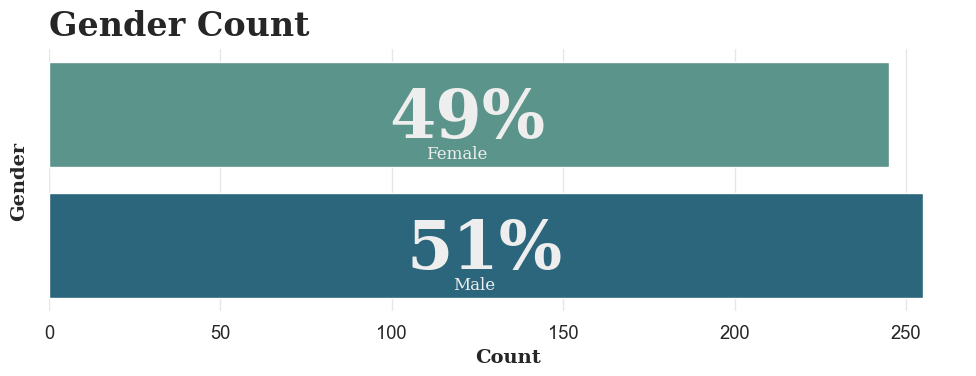

```
Number of Male: 255
Number of Female: 245
```

```python
# Edit seaborn style
plt.figure(figsize=(10, 4))
sns.set_context('notebook',  font_scale=1.2)
# Set grid color
sns.set_style('whitegrid', {'grid.color': '0.9'})
# Remove the frame
plt.box(False)

# Plot bar plot
sns.countplot(y=cab_driver_df['gender'], palette="crest")

# Get actual numbers to annotate the plot
male = cab_driver_df['gender'].value_counts()[0]
female = cab_driver_df['gender'].value_counts()[1]
total = male + female

# Annotations
plt.annotate(f"{round((female/total)*100)}%", xy=(female//2, 0.03),
             va='center', ha='center', fontsize=48, fontweight='bold',
             fontfamily='serif', color='#eeeeee')
plt.annotate(f"Female", xy=(female//2-3, 0.3),
             va='center', ha='center', fontsize=12, fontweight='light',
             fontfamily='serif', color='#eeeeee')

plt.annotate(f"{round((male/total)*100)}%", xy=(male//2, 1.03),
                va='center', ha='center', fontsize=48, fontweight='bold',
                fontfamily='serif', color='#eeeeee')
plt.annotate(f"Male", xy=(male//2-3, 1.3),
                va='center', ha='center', fontsize=12, fontweight='light',
                fontfamily='serif', color='#eeeeee')

# Set labels
plt.xlabel('Count', fontsize=14, fontweight='bold', fontfamily='serif')
plt.ylabel('Gender', fontsize=14, fontweight='bold', fontfamily='serif', labelpad=15)
# Remove ticks
plt.yticks([])
plt.xticks()

# Set title
plt.title('Gender Count', fontsize=24, fontweight='bold', fontfamily='serif', loc='left', pad=10)

plt.tight_layout()
plt.show()

print(f"Number of Male: {male:,}")
print(f"Number of Female: {female:,}")
```

**Observations**

- There are slightly more male drivers compared to female drivers.

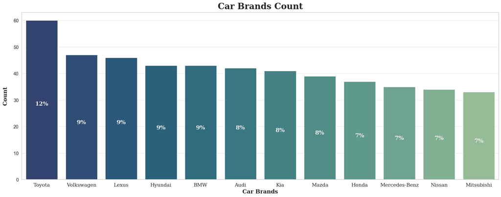

```python
fig, ax = plt.subplots(figsize=(20, 8))

car_brands = cab_driver_df['car_brand'].value_counts().index
counts = cab_driver_df['car_brand'].value_counts().values
total = counts.sum()

car_brands = car_brands[counts.argsort()[::-1]]
counts = counts[counts.argsort()[::-1]]

counts_df = pd.DataFrame({'car_brand': car_brands, 'counts': counts})

ax1 = sns.barplot(counts_df, x=counts_df.index, y='counts', palette='crest_r', ax=ax)

# Set labels
plt.xlabel('Car Brands', fontsize=16, fontweight='bold', fontfamily='serif')
plt.ylabel('Count', fontsize=16, fontweight='bold', fontfamily='serif', labelpad=15)

# Set xticks to be car brands
plt.xticks(range(len(car_brands)), car_brands, fontsize=14, fontfamily='serif')

# Set title
plt.title('Car Brands Count', fontsize=24, fontweight='bold', fontfamily='serif', loc='center', pad=10)

# Annotations
for p in ax1.patches:
    height = p.get_height()
    ax1.text(p.get_x()+p.get_width()/2., height//2 - 2, f"{round(height/total*100)}%", ha="center", fontsize=16, fontweight='bold', fontfamily='serif', color='#eeeeee')

plt.tight_layout()
plt.show()

#
```

**Observations**

- Cab brand with the most drivers owning is toyota which makes up 12% of the total cars.

### Numerical Variables

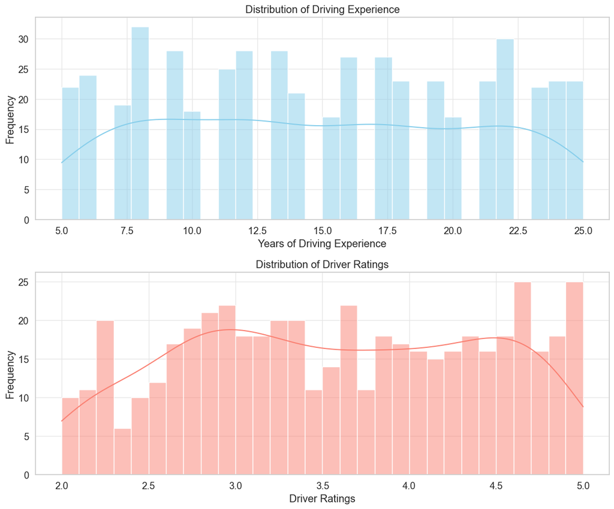

```python
# Plot a subplot of driving experience and driver ratings
fig, axes = plt.subplots(2, 1, figsize=(12, 10))

# Distribution of driving experience
sns.histplot(cab_driver_df['num_of_years_driving_exp'], ax=axes[0], kde=True, bins=30, color='skyblue')
axes[0].set_title("Distribution of Driving Experience")
axes[0].set_xlabel("Years of Driving Experience")
axes[0].set_ylabel("Frequency")

# Distribution of driver ratings
sns.histplot(cab_driver_df['driver_rating'], ax=axes[1], kde=True, bins=30, color='salmon')
axes[1].set_title("Distribution of Driver Ratings")
axes[1].set_xlabel("Driver Ratings")
axes[1].set_ylabel("Frequency")

plt.tight_layout()
plt.show()
```

**Observations**

- Distribution of data seems made up as there is an equal amount of observations years of driving experience. There should be a distribution if data is collected in real life.
- Tri-Normal distribution for driver ratings as there are peak values when ratings is 2.9, 3.6 and 4.6.

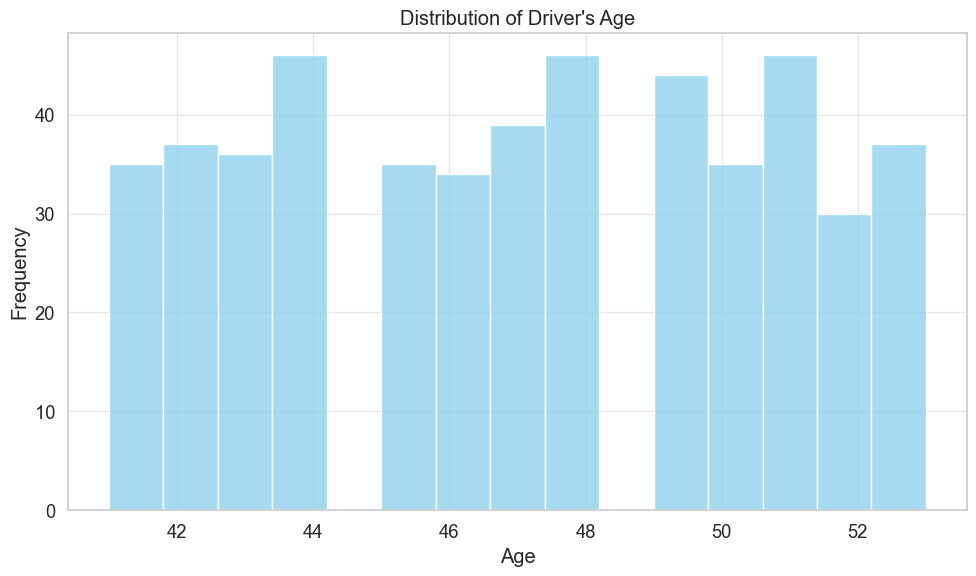

```python
# Plot the distribution of age
plt.figure(figsize=(10, 6))
age_plot = sns.histplot(cab_driver_df['driver_age'], kde=False, bins=15, color='skyblue')
age_plot.set_title("Distribution of Driver's Age")
age_plot.set_xlabel("Age")
age_plot.set_ylabel("Frequency")

plt.tight_layout()
plt.show()
```

**Observations**

- Mainly, there can be three age groups, 41-44. 45-48 and 49-53.

```python
numerical_columns = cab_driver_df.select_dtypes(include=['number']).columns
numerical_data = cab_driver_df[numerical_columns].drop(['driver_id', 'car_model_year'], axis=1)
display(numerical_data.head())
```

|  | num_of_years_driving_exp | driver_rating | driver_age | car_age |
| --- | --- | --- | --- | --- |
| 0 | 10 | 3.800781 | 41 | 13 |
| 1 | 14 | 2.800781 | 46 | 23 |
| 2 | 13 | 3.800781 | 47 | 24 |
| 3 | 16 | 2.199219 | 41 | 14 |
| 4 | 20 | 2.699219 | 45 | 11 |

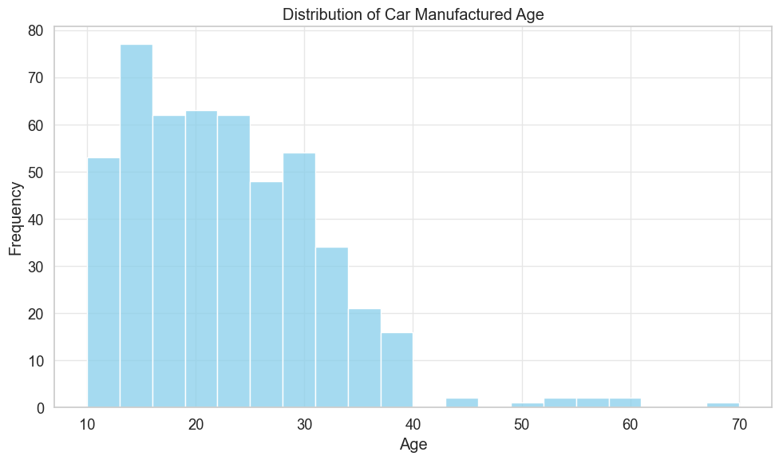

```python
# Plot the distribution of car manufactured age
plt.figure(figsize=(10, 6))

# Plot the distribution of age
plt.figure(figsize=(10, 6))
car_age_plt = sns.histplot(cab_driver_df['car_age'], kde=False, bins=20, color='skyblue')
car_age_plt.set_title("Distribution of Car Manufactured Age")
car_age_plt.set_xlabel("Age")
car_age_plt.set_ylabel("Frequency")

plt.tight_layout()
plt.show()
```

**Observations**

### Bivariate Relationship

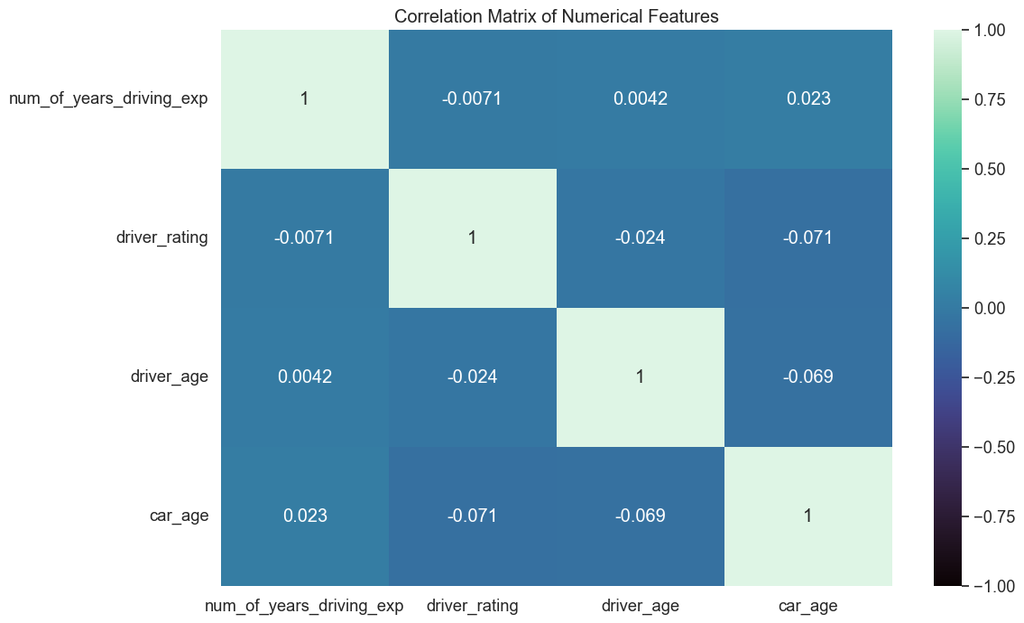

```python
correlation_matrix = numerical_data.corr()

# Plot the correlation matrix
plt.figure(figsize=(12, 8))
corr_heatmap = sns.heatmap(correlation_matrix, annot=True, cmap='mako', vmin=-1, vmax=1)
corr_heatmap.set_title("Correlation Matrix of Numerical Features")
plt.show()
```

**Observations**

- All of the numerical features for driver have a weak correlation with one another which means there are no significant relationship between the variables.

### Gender VS Driver Ratings

#### Distribution of Driver Ratings by Gender

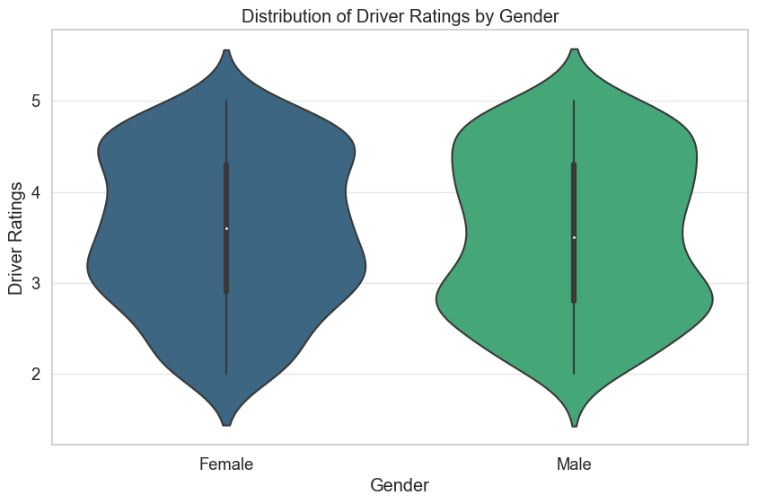

```python
# Plotting the distribution of driver ratings by Gender
plt.figure(figsize=(10, 6))

driver_rating_plt = sns.violinplot(x='gender', y='driver_rating', data=cab_driver_df, palette='viridis')
plt.title("Distribution of Driver Ratings by Gender")
plt.xlabel("Gender")
plt.ylabel("Driver Ratings")
plt.show()
```

**Observations**

- On average, males and females have an equal distribution of driver ratings.

#### Chi-Square Contingency Test

- A deeper dive into the respective bins of driver ratings, split into different bins
- Use of chi-square to find out how driver ratings was being given based on drivers' ratings

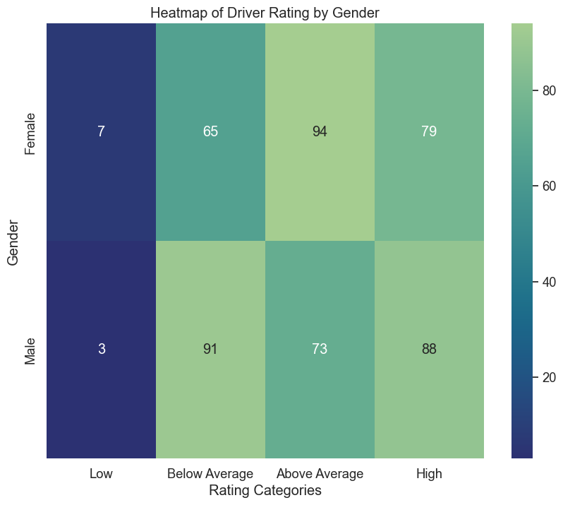

```
{'Chi-Square Statistic': 8.862626887082175,
 'P-Value': 0.03117420853879594,
 'Degrees of Freedom': 3,
 'Expected Frequencies': array([[ 4.9 , 76.44, 81.83, 81.83],
        [ 5.1 , 79.56, 85.17, 85.17]])}
```

```python
df_eda = cab_driver_df.copy()

rating_categories = pd.cut(df_eda['driver_rating'], bins=[0, 2, 3, 4, 5], include_lowest=True,
                           labels=['Low', 'Below Average', 'Above Average', 'High'])

# Create a new column 'rating_categories' based on the driver_rating
df_eda['rating_categories'] = rating_categories

# Cross tabulation
contingency_table = pd.crosstab(df_eda['gender'], df_eda['rating_categories'])

# Perform the chi-square test
chi2, p_value, dof, expected = chi2_contingency(contingency_table)

# Plot the heatmap
plt.figure(figsize=(10, 8))
sns.heatmap(contingency_table, annot=True,fmt='d', cmap='crest_r')
plt.title('Heatmap of Driver Rating by Gender')
plt.xlabel('Rating Categories')
plt.ylabel('Gender')

plt.show()

# Output the results of chi-square test
chi2_sq_results = {
    'Chi-Square Statistic': chi2,
    'P-Value': p_value,
    'Degrees of Freedom': dof,
    'Expected Frequencies': expected
}

chi2_sq_results
```

**Observations**

- We can see that there are a very small amount of drivers who have low ratings.
- We can also see that there are greater number of female drivers with above average driver ratings (3<=x<4) but greater number of male drivers with below average (2<=x<3) and high driver ratings (4<=x).
- Previously, it is seen that on average it was equal because the male with high ratings balance out the below average ratings to match the amount of above average ratings that the females have received.
- Test results indicate that there is a statistically significant association between gender and driver rating categories, as p-value of 0.03 is less than the p-value bench mark of 0.05, suggesting that driver ratings may be influenced by gender.

### Average Driver Ratings based on Car Brand

- Plot a bar chart to show the average driver rating based on car brand

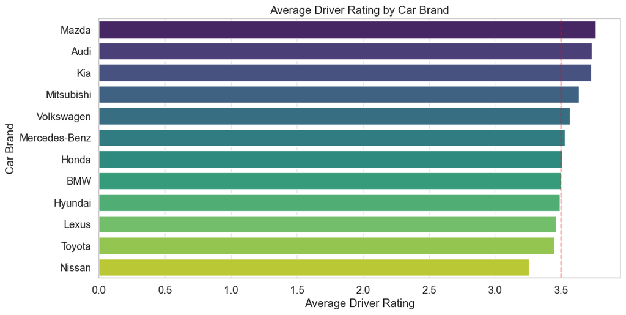

```python
# Group by car brand and calculate the average driver ratings
avg_rating_by_car_brand = cab_driver_df.groupby('car_brand')['driver_rating'].mean().sort_values(ascending=False).reset_index()

# Plot the bar graph
plt.figure(figsize=(12, 6))

# Plot the bar graph by sorting the average driver ratings
sns.barplot(x='driver_rating', y='car_brand', data=avg_rating_by_car_brand, palette='viridis', order=avg_rating_by_car_brand['car_brand'])
plt.title("Average Driver Rating by Car Brand")
plt.xlabel("Average Driver Rating")
plt.ylabel("Car Brand")

# Plot a vertical line as threshold to show car brands with average driver ratings above the thershold
plt.axvline(x=3.5, color='red',alpha=0.5, linestyle='--', label="Threshold")
plt.show()
```

**Observations**

- Bar graph shows that Mazda, Audi, Kia, Mitsubishi, Volkswagen, Mercedes-Benz, Honda, BMW have an average driver rating that surpassed the threshold of 3.5, which may suggest that the riders have a comforting and comfortable ride when sitting in these car models.
- Nissan has the least average driver ratings, might be due to the noise produced by the engines compared to more luxurious brands like BMW and Audi.

### Clustering

- A type of unsupervised machine learning method that involves grouping similar data points together.
- Identify inherent structures or patterns within a dataset without the need of labeled outcomes.
- K-Means Clustering is used:
  - Aims to partition a set of data points into meaningful subgroups or clusters based on their similarities
  - Each data point belongs to the cluster with the nearest mean

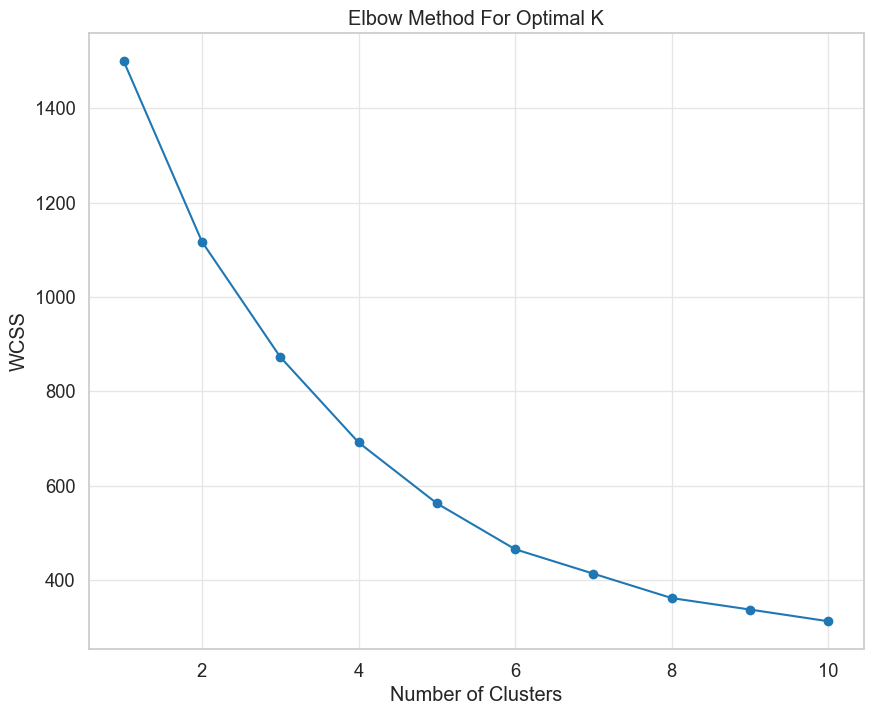

```python
driver_numerical = ['num_of_years_driving_exp', 'driver_rating', 'driver_age']
X = cab_driver_df[driver_numerical]

# Standardize the data
scaler = StandardScaler()
X_scaled = scaler.fit_transform(X)

# Using the optimal number of clusters from the elbow method
wcss = []
for i in range(1, 11):
    kmeans = KMeans(n_clusters = i, init='k-means++', random_state=42, n_init=10, max_iter=300)
    kmeans.fit(X_scaled)
    wcss.append(kmeans.inertia_)

# Plot the elbow method graph
plt.figure(figsize=(10, 8))
plt.plot(range(1, 11), wcss, marker='o', linestyle='-')
plt.title("Elbow Method For Optimal K")
plt.xlabel("Number of Clusters")
plt.ylabel("WCSS")
plt.show()
```

**Observations**

- Even though elbow plot does not reveal how many clusters is the optimal number to use, 4 would be the most logical number to draw conclusions from.

```python
# Use K-Means clustering
n_clusters = 4
kmeans = KMeans(n_clusters=n_clusters, init='k-means++', random_state=42, max_iter=300, n_init=10)
kmeans.fit(X_scaled)

# Create a copy of the dataframe
cab_driver_df_cluster = cab_driver_df.copy()

# Add the cluster labels
cab_driver_df_cluster['cluster'] = kmeans.labels_
display(cab_driver_df_cluster.head())
```

|  | driver_id | driver_name | date_of_birth | num_of_years_driving_exp | gender | car_brand | car_model_year | driver_rating | driver_age | car_age | cluster |
| --- | --- | --- | --- | --- | --- | --- | --- | --- | --- | --- | --- |
| 0 | 1 | Sinclair Birmingham | 1982-10-17 | 10 | Male | Audi | 2010 | 3.800781 | 41 | 13 | 2 |
| 1 | 2 | Juline Faulks | 1977-11-30 | 14 | Female | BMW | 2000 | 2.800781 | 46 | 23 | 0 |
| 2 | 3 | Germayne Stit | 1976-09-18 | 13 | Male | Mercedes-Benz | 1999 | 3.800781 | 47 | 24 | 1 |
| 3 | 4 | Athena Coudray | 1982-10-24 | 16 | Female | Lexus | 2009 | 2.199219 | 41 | 14 | 0 |
| 4 | 5 | Batholomew Hiscoke | 1978-09-11 | 20 | Male | BMW | 2012 | 2.699219 | 45 | 11 | 2 |

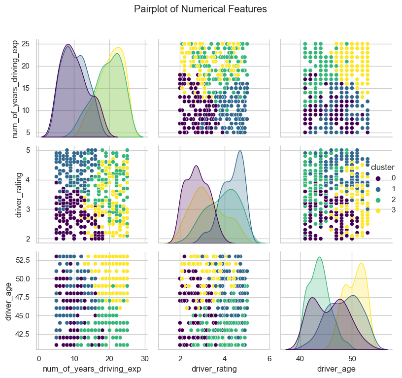

```python
sns.set(style='whitegrid', palette='muted')

pairplot_fig = sns.pairplot(cab_driver_df_cluster, vars=driver_numerical, hue='cluster', palette='viridis')
pairplot_fig.fig.suptitle("Pairplot of Numerical Features", y=1.02)

plt.tight_layout()
plt.show()
```

**Observations**

- From the clusters that can be formed, we can see that Cluster 0 and 1 have drivers with fewer number of driving experience years whereas Cluster 2 and 3 have drivers with higher number of driving experience years.
- Another observation is that Cluster 1 has drivers with higher number of driver ratings whereas Cluster 0 has drivers with fewer number of driver ratings whereas Cluster 2 and 3 has a mix of both high and low driver ratings.
- Last observation is that Cluster 2 has more drivers who are near middle-aged slightly above 40, while Cluster 3 has more drivers who are slightly towards the older age of 50 and above.
- Note that the clusters formed are not extremely well defined as 4 is still not the optimal number of clusters.

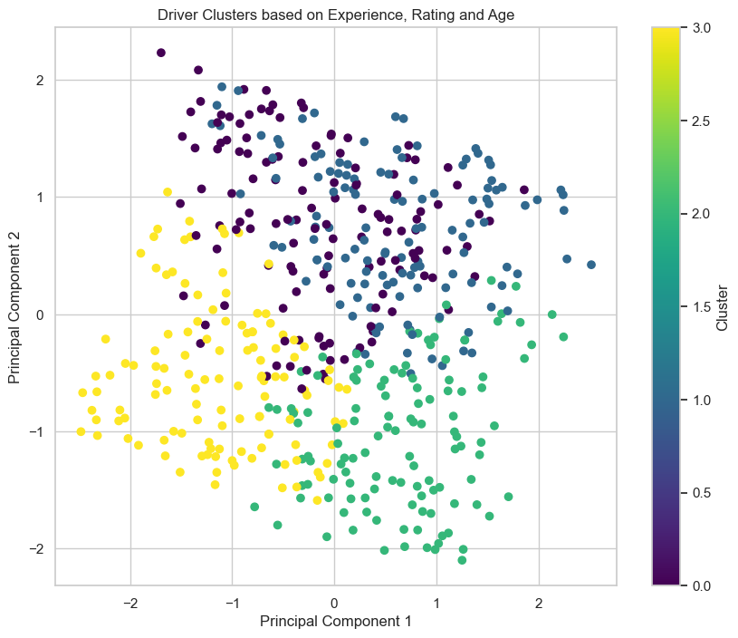

```
Centroids of clusters in original feature space
Cluster 0: {'num_of_years_driving_exp': 10.21, 'driver_rating': 2.76, 'driver_age': 45.69}
Cluster 1: {'num_of_years_driving_exp': 10.17, 'driver_rating': 4.31, 'driver_age': 48.39}
Cluster 2: {'num_of_years_driving_exp': 19.48, 'driver_rating': 3.89, 'driver_age': 43.71}
Cluster 3: {'num_of_years_driving_exp': 20.27, 'driver_rating': 3.25, 'driver_age': 50.4}
```

```python
# Using PCA to reduce the dimensionality of the data
pca = PCA(n_components=2)
X_pca = pca.fit_transform(X_scaled)

# Plot the clusters
plt.figure(figsize=(10, 8))
plt.scatter(X_pca[:,0], X_pca[:,1], c=kmeans.labels_, cmap='viridis', marker='o')
plt.title("Driver Clusters based on Experience, Rating and Age")
plt.xlabel("Principal Component 1")
plt.ylabel("Principal Component 2")
plt.colorbar(label='Cluster')
plt.show()

# Display centroids
centroids = scaler.inverse_transform(kmeans.cluster_centers_)
print(f'Centroids of clusters in original feature space')
for i, c in enumerate(centroids):
    print(f'Cluster {i}: {dict(zip(driver_numerical, np.round(c, 2)))}')
```

**Observations**

### Cluster Profiling

```python
# Drop the columns that are not required
cab_driver_df_cluster.drop(['driver_id', 'driver_name' ,'date_of_birth', 'car_model_year', "gender", "car_brand", "car_age"], axis =1 , inplace=True)

# Cluster profiling  to understand the characteristics of the cluster
cluster_profile = cab_driver_df_cluster.groupby('cluster').mean()

# Display the mean values of each feature for each cluster
display(cluster_profile)
```

| cluster | num_of_years_driving_exp | driver_rating | driver_age |
| --- | --- | --- | --- |
| 0 | 10.209302 | 2.761719 | 45.689922 |
| 1 | 10.165354 | 4.312500 | 48.385827 |
| 2 | 19.479675 | 3.888672 | 43.707317 |
| 3 | 20.272727 | 3.248047 | 50.404959 |

**Observations**

- Cluster 0 is made up of drivers with low number of driving experiences, age is about 46 (considered average within the dataset range) and has lower driver rating (2.76).
- Cluster 1 is made up of drivers with low number of driving experiences, age is about 48 (considered average within the dataset range) and has high driver rating (about 4.3)
- As seen from the cluster profiling, cluster 2 is made up of drivers with high number of driving experiences, age is closer to 40 (younger) and has average driver rating.
- Cluster 3 is made up of drivers with high number of driving experiences, age is closer to 50 (older) and has average driver rating.

### Anomaly Detection

```python
iso_forest = IsolationForest(n_estimators=100, contamination=0.01, random_state=42)
cab_driver_df_cluster['anomaly'] = iso_forest.fit_predict(X_scaled)

# Count the number of anomalies detected
anomaly_count = cab_driver_df_cluster['anomaly'].value_counts()

# Display the count of anomalies and non-anomalies
print(f"Count of anomalies (-1) and non anomalies (1):")
print(anomaly_count)

# Display the anomalies
print(f"\nA few anomalies detected:")
display(cab_driver_df_cluster[cab_driver_df_cluster['anomaly'] == -1].head())
```

```
Count of anomalies (-1) and non anomalies (1):
 1    495
-1      5
Name: anomaly, dtype: int64

A few anomalies detected:
```

|  | num_of_years_driving_exp | driver_rating | driver_age | cluster | anomaly |
| --- | --- | --- | --- | --- | --- |
| 66 | 25 | 5.000000 | 47 | 2 | -1 |
| 67 | 5 | 2.199219 | 53 | 0 | -1 |
| 183 | 5 | 2.000000 | 43 | 0 | -1 |
| 249 | 25 | 2.099609 | 41 | 2 | -1 |
| 409 | 25 | 5.000000 | 49 | 2 | -1 |

### Anomaly Detection

- IsolationForest is used for anomaly detection and is effective for identifying outliers or anomalies in the dataset.
- IsolationForest:
  - Identify patterns or instances that deviate significantly from expected behaviour of the dataset.
  - Isolates anomalies by recursively partitioning the data into subsets
  - Randomly selects a feature and a split value for each partitioning
  - Anomalies are expected to have shorter paths in the resulting trees, usually isolated with fewer splits.
  - Performs well in high-dimensional space

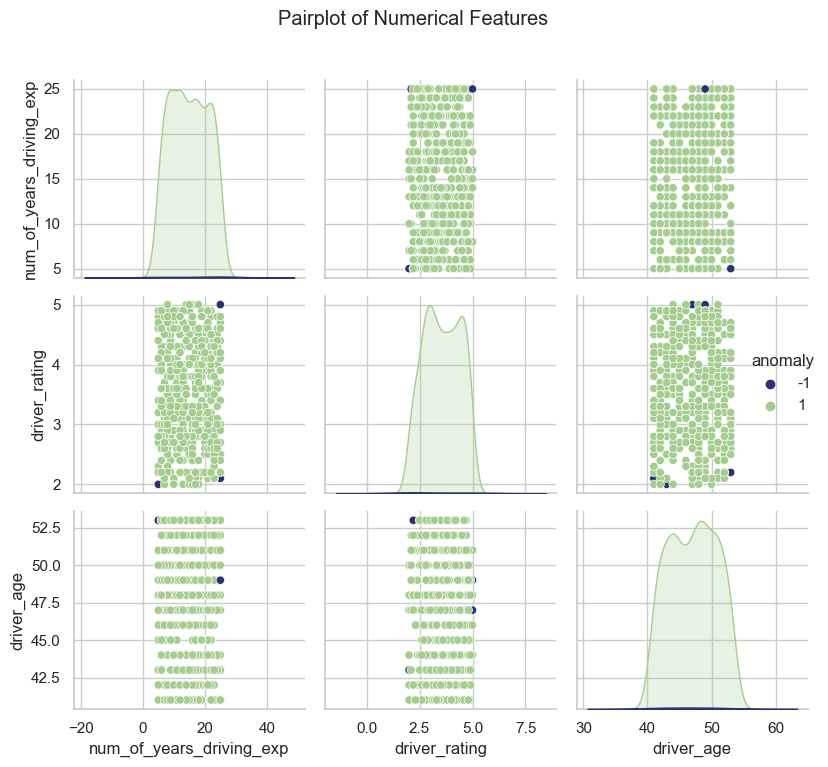

```python
pairplot_fig = sns.pairplot(cab_driver_df_cluster, vars=driver_numerical, hue='anomaly', palette='crest_r')
pairplot_fig.fig.suptitle("Pairplot of Numerical Features", y=1.02)

plt.tight_layout()
plt.show()
```

**Observations**

- After looking at the anomalies, it is found that the anomalies have these traits:
  - High number of driving experience years and perfect driver ratings but average age
  - Extremely low number of driving experience years but low driver ratings and old age
  - Extremely low number of driving experience years and younger age (around 43) but low driver ratings

```
No artists with labels found to put in legend.  Note that artists whose label start with an underscore are ignored when legend() is called with no argument.
```

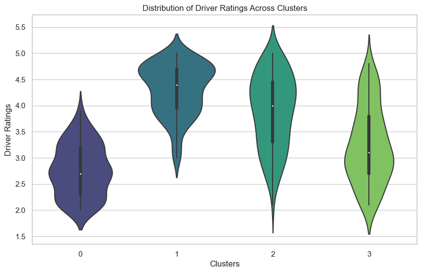

```python
# Plotting the distribution of driver ratings across clusters
plt.figure(figsize=(10, 6))

sns.violinplot(x='cluster', y='driver_rating', data=cab_driver_df_cluster, palette='viridis')
plt.title("Distribution of Driver Ratings Across Clusters")
plt.xlabel("Clusters")
plt.ylabel("Driver Ratings")
plt.xticks(range(n_clusters), range(n_clusters))
# Remove the legend
plt.legend().remove()
plt.show()
```

**Observations**

- Cluster 2 and 3 have an average number of driver ratings while Cluster 0 has a lower average driver ratings and Cluster 1 has a higher amount of driver ratings.

#### Pandas Profiling

```python
Profile = ProfileReport(cab_driver_df, title='Pandas Profiling Report', explorative=True)
Profile.to_widgets()
```

[output not shown]

### Sensor Safety

#### Numerical Variables

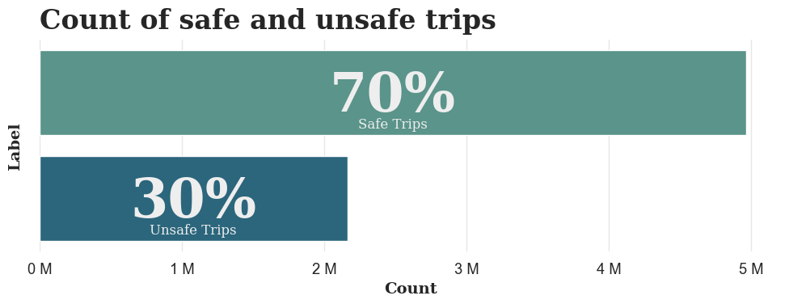

```
Number of safe trips: 4,964,046
Number of unsafe trips: 2,162,640
```

```python
# Edit seaborn style
plt.figure(figsize=(10, 4))
sns.set_context('notebook',  font_scale=1.2)
# Set grid color
sns.set_style('whitegrid', {'grid.color': '0.9'})
# Remove the frame
plt.box(False)

# Plot bar plot
sns.countplot(y=sensor_safety_df['label'], palette="crest")

# Get actual numbers to annotate the plot
safe = sensor_safety_df['label'].value_counts()[0]
unsafe = sensor_safety_df['label'].value_counts()[1]
total = safe + unsafe

# Annotations
plt.annotate(f"{round((safe/total)*100)}%", xy=(safe//2, 0.03),
             va='center', ha='center', fontsize=48, fontweight='bold',
             fontfamily='serif', color='#eeeeee')
plt.annotate(f"Safe Trips", xy=(safe//2-3, 0.3),
             va='center', ha='center', fontsize=12, fontweight='light',
             fontfamily='serif', color='#eeeeee')

plt.annotate(f"{round((unsafe/total)*100)}%", xy=(unsafe//2, 1.03),
                va='center', ha='center', fontsize=48, fontweight='bold',
                fontfamily='serif', color='#eeeeee')
plt.annotate(f"Unsafe Trips", xy=(unsafe//2-3, 1.3),
                va='center', ha='center', fontsize=12, fontweight='light',
                fontfamily='serif', color='#eeeeee')

# Set labels
plt.xlabel('Count', fontsize=14, fontweight='bold', fontfamily='serif')
plt.ylabel('Label', fontsize=14, fontweight='bold', fontfamily='serif', labelpad=15)
# Remove ticks
plt.yticks([])
plt.xticks()
# Remove standard notation in x-axis
plt.ticklabel_format(axis='x', useOffset=False, style='plain')
# Format x-axis ticks to remove 6 zeros and replace it with 'M'
plt.gca().xaxis.set_major_formatter(lambda x, _: f"{int(x / 1000000)} M")

# Set title
plt.title('Count of safe and unsafe trips', fontsize=24, fontweight='bold', fontfamily='serif', loc='left', pad=10)

plt.tight_layout()
plt.show()

print(f"Number of safe trips: {safe:,}")
print(f"Number of unsafe trips: {unsafe:,}")
```

**Observations**:

- As expected, most of our trips are actually considered safe with only a few of the trips being unsafe (30 percent)

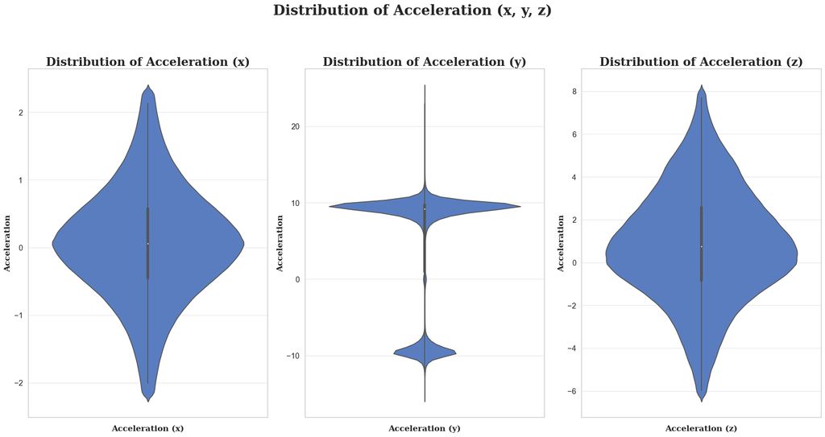

```python
# Do a violin plot of acceleration (x, y, z)
fig, ax = plt.subplots(1, 3, figsize=(20, 10))

df_eda = sensor_safety_df[['acceleration_x', 'acceleration_y', 'acceleration_z']]

# Get only those within IQR
lower_boundx, upper_boundx = calc_gates(df_eda['acceleration_x'])
df_eda = df_eda[(df_eda['acceleration_x'] > lower_boundx) & (df_eda['acceleration_x'] < upper_boundx)]
lower_boundy, upper_boundy = calc_gates(df_eda['acceleration_y'])
df_eda = df_eda[(df_eda['acceleration_y'] > lower_boundy) & (df_eda['acceleration_y'] < upper_boundy)]
lower_boundz, upper_boundz = calc_gates(df_eda['acceleration_z'])
df_eda = df_eda[(df_eda['acceleration_z'] > lower_boundz) & (df_eda['acceleration_z'] < upper_boundz)]

sns.violinplot(y=df_eda['acceleration_x'], ax=ax[0])
sns.violinplot(y=df_eda['acceleration_y'], ax=ax[1])
sns.violinplot(y=df_eda['acceleration_z'], ax=ax[2])

ax[0].set_xlabel('Acceleration (x)', fontsize=14, fontweight='bold', fontfamily='serif')
ax[1].set_xlabel('Acceleration (y)', fontsize=14, fontweight='bold', fontfamily='serif')
ax[2].set_xlabel('Acceleration (z)', fontsize=14, fontweight='bold', fontfamily='serif')

ax[0].set_ylabel('Acceleration', fontsize=14, fontweight='bold', fontfamily='serif')
ax[1].set_ylabel('Acceleration', fontsize=14, fontweight='bold', fontfamily='serif')
ax[2].set_ylabel('Acceleration', fontsize=14, fontweight='bold', fontfamily='serif')

ax[0].set_title('Distribution of Acceleration (x)', fontsize=20, fontweight='bold', fontfamily='serif')
ax[1].set_title('Distribution of Acceleration (y)', fontsize=20, fontweight='bold', fontfamily='serif')
ax[2].set_title('Distribution of Acceleration (z)', fontsize=20, fontweight='bold', fontfamily='serif')

plt.suptitle('Distribution of Acceleration (x, y, z)', fontsize=24, fontweight='bold', fontfamily='serif', y=1.05)

plt.tight_layout()
plt.show()
```

**Observations**

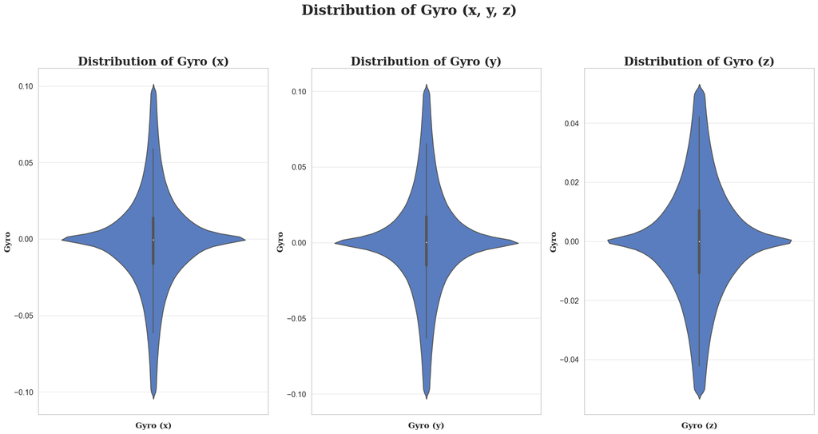

```python
# Do a violin plot of gyro (x, y, z)
fig, ax = plt.subplots(1, 3, figsize=(20, 10))

df_eda = sensor_safety_df.copy()

# Get only those within IQR
lower_boundx, upper_boundx = calc_gates(df_eda['gyro_x'], gate_scale=1.5)
df_eda = df_eda[(df_eda['gyro_x'] > lower_boundx) & (df_eda['gyro_x'] < upper_boundx)]
lower_boundy, upper_boundy = calc_gates(df_eda['gyro_y'], gate_scale=1.5)
df_eda = df_eda[(df_eda['gyro_y'] > lower_boundy) & (df_eda['gyro_y'] < upper_boundy)]
lower_boundz, upper_boundz = calc_gates(df_eda['gyro_z'], gate_scale=1.5)
df_eda = df_eda[(df_eda['gyro_z'] > lower_boundz) & (df_eda['gyro_z'] < upper_boundz)]


sns.violinplot(y=df_eda['gyro_x'], ax=ax[0])
sns.violinplot(y=df_eda['gyro_y'], ax=ax[1])
sns.violinplot(y=df_eda['gyro_z'], ax=ax[2])

ax[0].set_xlabel('Gyro (x)', fontsize=14, fontweight='bold', fontfamily='serif')
ax[1].set_xlabel('Gyro (y)', fontsize=14, fontweight='bold', fontfamily='serif')
ax[2].set_xlabel('Gyro (z)', fontsize=14, fontweight='bold', fontfamily='serif')

ax[0].set_ylabel('Gyro', fontsize=14, fontweight='bold', fontfamily='serif')
ax[1].set_ylabel('Gyro', fontsize=14, fontweight='bold', fontfamily='serif')
ax[2].set_ylabel('Gyro', fontsize=14, fontweight='bold', fontfamily='serif')

ax[0].set_title('Distribution of Gyro (x)', fontsize=20, fontweight='bold', fontfamily='serif')
ax[1].set_title('Distribution of Gyro (y)', fontsize=20, fontweight='bold', fontfamily='serif')
ax[2].set_title('Distribution of Gyro (z)', fontsize=20, fontweight='bold', fontfamily='serif')

plt.suptitle('Distribution of Gyro (x, y, z)', fontsize=24, fontweight='bold', fontfamily='serif', y=1.05)

plt.tight_layout()
plt.show()
```

**Observations**

- Gyro_x, Gyro_y and Gyro_z have a mean value of 0 radians per second and a non-normal distribution

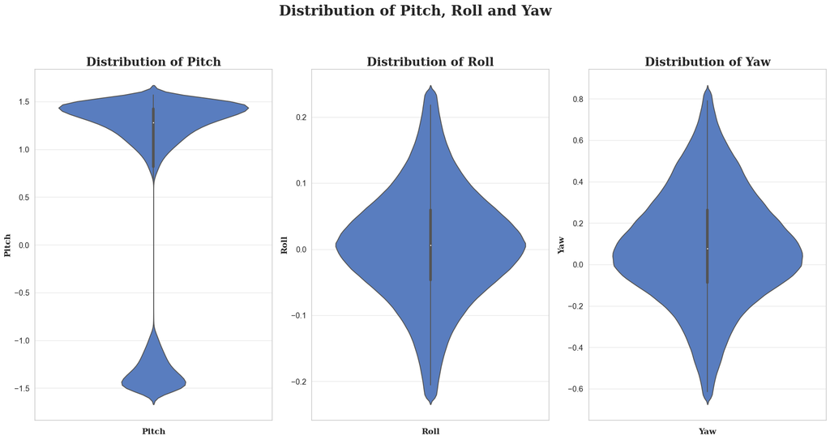

```python
# Do a violin plot of pitch, roll and yaw
fig, ax = plt.subplots(1, 3, figsize=(20, 10))

df_eda = sensor_safety_df.copy()

# Get only those within IQR
lower_boundx, upper_boundx = calc_gates(df_eda['pitch'], gate_scale=1.5)
df_eda = df_eda[(df_eda['pitch'] > lower_boundx) & (df_eda['pitch'] < upper_boundx)]
lower_boundy, upper_boundy = calc_gates(df_eda['roll'], gate_scale=1.5)
df_eda = df_eda[(df_eda['roll'] > lower_boundy) & (df_eda['roll'] < upper_boundy)]
lower_boundz, upper_boundz = calc_gates(df_eda['yaw'], gate_scale=1.5)
df_eda = df_eda[(df_eda['yaw'] > lower_boundz) & (df_eda['yaw'] < upper_boundz)]

sns.violinplot(y=df_eda['pitch'], ax=ax[0])
sns.violinplot(y=df_eda['roll'], ax=ax[1])
sns.violinplot(y=df_eda['yaw'], ax=ax[2])

ax[0].set_xlabel('Pitch', fontsize=14, fontweight='bold', fontfamily='serif')
ax[1].set_xlabel('Roll', fontsize=14, fontweight='bold', fontfamily='serif')
ax[2].set_xlabel('Yaw', fontsize=14, fontweight='bold', fontfamily='serif')

ax[0].set_ylabel('Pitch', fontsize=14, fontweight='bold', fontfamily='serif')
ax[1].set_ylabel('Roll', fontsize=14, fontweight='bold', fontfamily='serif')
ax[2].set_ylabel('Yaw', fontsize=14, fontweight='bold', fontfamily='serif')

ax[0].set_title('Distribution of Pitch', fontsize=20, fontweight='bold', fontfamily='serif')
ax[1].set_title('Distribution of Roll', fontsize=20, fontweight='bold', fontfamily='serif')
ax[2].set_title('Distribution of Yaw', fontsize=20, fontweight='bold', fontfamily='serif')

plt.suptitle('Distribution of Pitch, Roll and Yaw', fontsize=24, fontweight='bold', fontfamily='serif', y=1.05)

plt.tight_layout()
plt.show()
```

**Observations**

- Roll and Yaw has a mean value of $ 0 rad^2 $ and a normal distribution
- Pitch which is the tilting angle when going upslope or downslope is mainly around the values of 1.5 and -1.5

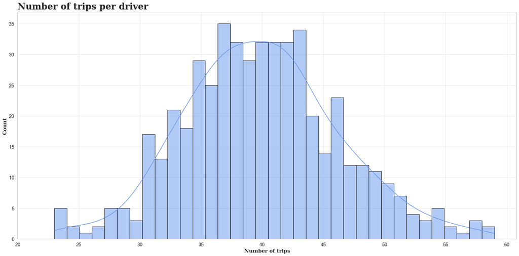

```python
# Get counts of trips per driver
df_eda = sensor_safety_df.copy()
# Group by driver_id and count all unique booking_id
df_eda = df_eda.groupby('driver_id')['booking_id'].nunique().reset_index()
# Rename column
df_eda.rename({'booking_id': 'count'}, axis=1, inplace=True)
# Sort by count
df_eda.sort_values(by='count', ascending=False, inplace=True)
# Reset index
df_eda.reset_index(drop=True, inplace=True)

# Plot bar plot
plt.figure(figsize=(20, 10))

# Plot histogram
sns.histplot(df_eda['count'], bins=35, kde=True, color='#6495ED', edgecolor='black', alpha=0.5)

# Set labels
plt.xlabel('Number of trips', fontsize=14, fontweight='bold', fontfamily='serif')
plt.ylabel('Count', fontsize=14, fontweight='bold', fontfamily='serif')

# Set title
plt.title('Number of trips per driver', fontsize=24, fontweight='bold', fontfamily='serif', loc='left', pad=10)

# Set xticks to be every 10
plt.xticks(np.arange(20, 61, 5))

plt.tight_layout()
plt.show()
```

**Observations**:

- The number of trips per driver range from around 20 to 60
- The distribution of the number of trips is normally distributed

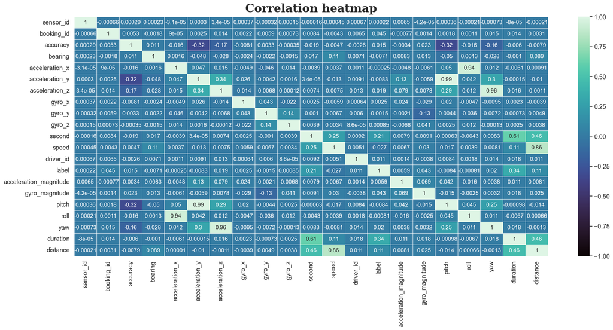

```python
# Plot heatmap
plt.figure(figsize=(20, 10))

sns.heatmap(sensor_safety_df.corr(), annot=True, vmin=-1, vmax=1, linewidths=0.5, annot_kws={'fontsize': 12}, cmap='mako')

plt.title('Correlation heatmap', fontsize=24, fontweight='bold', fontfamily='serif', loc='center', pad=10)

plt.tight_layout()
plt.show()
```

**Observations**:

- As seen from the correlation matrix, there is not much correlation between the different columns except for the columns we engineered ourselves such as pitch, roll yaw, duration and distance

#### Sensor and Cab Drivers

Merging Sensor and Cab Driver dataframe for EDA

```python
# Merge Sensor Safety and Cab Driver on Driver ID
df = pd.merge(sensor_safety_df, cab_driver_df, on='driver_id', how='inner')
```

```python
# Group by booking_id
df_eda = df.copy()
df_eda = df_eda.groupby('booking_id').aggregate({'driver_id': 'first', 'label': 'first', 'gender': 'first', 'driver_rating': 'first', 'car_age': 'first', 'num_of_years_driving_exp': 'first', 'driver_age': 'first', 'car_model_year': 'first'}).reset_index()

# Then group by driver_id
df_eda = df_eda.groupby('driver_id').aggregate({'booking_id': 'count', 'label': 'mean', 'gender': 'first', 'driver_rating': 'first', 'car_age': 'first', 'num_of_years_driving_exp': 'first', 'driver_age': 'first', 'car_model_year': 'first'}).reset_index()
# Rename booking_id to num_of_trips
df_eda.rename({'booking_id': 'num_of_trips', 'label': 'percentage_of_unsafe_trips'}, axis=1, inplace=True)
# Multiply by 100 to get percentage
df_eda['percentage_of_unsafe_trips'] = df_eda['percentage_of_unsafe_trips'] * 100
display(df_eda.head())
```

|  | driver_id | num_of_trips | percentage_of_unsafe_trips | gender | driver_rating | car_age | num_of_years_driving_exp | driver_age | car_model_year |
| --- | --- | --- | --- | --- | --- | --- | --- | --- | --- |
| 0 | 1 | 41 | 29.268293 | Male | 3.800781 | 13 | 10 | 41 | 2010 |
| 1 | 2 | 47 | 34.042553 | Female | 2.800781 | 23 | 14 | 46 | 2000 |
| 2 | 3 | 38 | 42.105263 | Male | 3.800781 | 24 | 13 | 47 | 1999 |
| 3 | 4 | 33 | 27.272727 | Female | 2.199219 | 14 | 16 | 41 | 2009 |
| 4 | 5 | 42 | 14.285714 | Male | 2.699219 | 11 | 20 | 45 | 2012 |

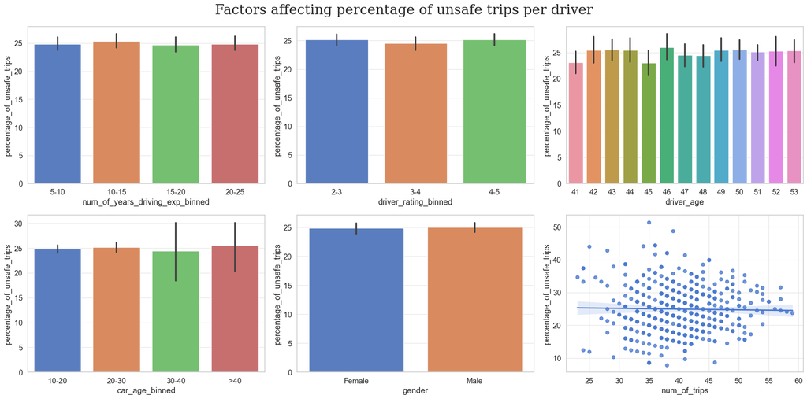

```python
# Bin the num_of_years_driving_exp into 8 bins
df_eda['num_of_years_driving_exp_binned'] = pd.cut(df_eda['num_of_years_driving_exp'], bins=4, include_lowest=True, labels=['5-10', '10-15', '15-20', '20-25'])

# Bin the driver_rating into 3 bins
df_eda['driver_rating_binned'] = pd.cut(df_eda['driver_rating'], bins=3, include_lowest=True, labels=['2-3', '3-4', '4-5'])

# Check percentage of unsafe trips compared to 1. num_of_years_driving_exp, 2. driver_rating, 3. driver_age, 4. car_model_year, 5. gender, 6. num_of_trips
fig, ax = plt.subplots(2, 3, figsize=(20, 10))

# Bin the age
df_eda['car_age_binned'] = pd.cut(df_eda['car_age'], bins=4, include_lowest=True, labels=['10-20', '20-30', '30-40', '>40'])

# Plot scatter plot
sns.regplot(x='num_of_trips', y='percentage_of_unsafe_trips', data=df_eda, ax=ax[1][2])

# Plot bar plot
sns.barplot(x='num_of_years_driving_exp_binned', y='percentage_of_unsafe_trips', data=df_eda, ax=ax[0][0])
sns.barplot(x='driver_rating_binned', y='percentage_of_unsafe_trips', data=df_eda, ax=ax[0][1])
sns.barplot(x='driver_age', y='percentage_of_unsafe_trips', data=df_eda, ax=ax[0][2])
sns.barplot(x='car_age_binned', y='percentage_of_unsafe_trips', data=df_eda, ax=ax[1][0])
sns.barplot(x='gender', y='percentage_of_unsafe_trips', data=df_eda, ax=ax[1][1])

# Set title
plt.suptitle("Factors affecting percentage of unsafe trips per driver", fontfamily='serif', fontsize=24)

plt.tight_layout()
plt.show()
```

**Observations**:

- In general, it seems that for most factors, the percentage of unsafe trips are equally distributed for each bin
- For car age, we can see that even though the average percentage of unsafe trips per driver is around the same at 25%, the confidence interval for older cars such as 30-40 and >40 are much larger compared to the younger cars. This indicates that there is a higher variability in the safety of trips for older cars
- From the scatter plot, it seems that there is no correlation between number of trips per driver and percentage of unsafe trips per driver

```python
df_eda = df.copy()

df_eda = df_eda.groupby('booking_id').aggregate({'bearing': 'first', 'gyro_magnitude': 'first', 'acceleration_magnitude': 'first', 'duration': 'first', 'pitch': 'first', 'roll': 'first', 'yaw': 'first', 'car_brand': 'first', 'driver_age': 'first', 'car_age': 'first', 'gender': 'first'}).reset_index()
gender_freq = pd.DataFrame(df_eda.groupby(['car_brand', 'gender']).size()).reset_index()
# Rename column
gender_freq.rename({0: 'count'}, axis=1, inplace=True)
# Melt car brand and gender
gender_freq = gender_freq.pivot(index='car_brand', columns='gender', values='count').reset_index()
gender_freq = gender_freq.rename_axis(None, axis=1)

# Merge with df_eda
df_eda = df_eda.groupby('car_brand').aggregate({'bearing': 'mean', 'gyro_magnitude': 'mean', 'acceleration_magnitude': 'mean', 'duration': 'mean', 'pitch': 'mean', 'roll': 'mean', 'yaw': 'mean', 'driver_age': 'mean', 'car_age': 'mean'}).reset_index()
df_eda = df_eda.merge(gender_freq, on='car_brand', how='inner')

display(df_eda.head())
```

|  | car_brand | bearing | gyro_magnitude | acceleration_magnitude | duration | pitch | roll | yaw | driver_age | car_age | Female | Male |
| --- | --- | --- | --- | --- | --- | --- | --- | --- | --- | --- | --- | --- |
| 0 | Audi | 155.675842 | 0.169857 | 9.791112 | 914.484624 | 0.612797 | 0.005566 | 0.129243 | 47.301822 | 20.774487 | 734 | 1022 |
| 1 | BMW | 162.288757 | 0.134699 | 9.751209 | 921.840896 | 0.610969 | 0.003687 | 0.101141 | 46.887995 | 22.593912 | 1140 | 601 |
| 2 | Honda | 167.724884 | 0.130049 | 9.824466 | 903.354153 | 0.613163 | 0.004910 | 0.094680 | 46.768106 | 24.974751 | 764 | 741 |
| 3 | Hyundai | 163.326172 | 0.132611 | 9.751556 | 906.664144 | 0.644395 | 0.015224 | 0.111106 | 46.867870 | 22.176950 | 793 | 925 |
| 4 | Kia | 165.263596 | 0.131672 | 9.816129 | 914.871401 | 0.636011 | 0.005062 | 0.103627 | 47.031990 | 23.037108 | 776 | 787 |

```python
# Group by driver_id
df_eda = df.copy()
df_eda = df_eda.groupby('booking_id').aggregate({'driver_id': 'first', 'speed': 'mean', 'driver_rating': 'first', 'acceleration_magnitude': 'mean', 'duration': 'first', 'driver_age': 'first', 'gender': 'first'}).reset_index()

# Group by drivers and get their average speed
df_eda = df_eda.groupby('driver_id').aggregate({'speed': 'mean', 'driver_rating': 'first', 'acceleration_magnitude': 'mean', 'duration': 'mean', 'driver_age':'first', 'gender': 'first'}).reset_index()
display(df_eda.head())
```

|  | driver_id | speed | driver_rating | acceleration_magnitude | duration | driver_age | gender |
| --- | --- | --- | --- | --- | --- | --- | --- |
| 0 | 1 | 26.644532 | 3.800781 | 9.837441 | 792.146341 | 41 | Male |
| 1 | 2 | 28.783123 | 2.800781 | 9.785679 | 946.255319 | 46 | Female |
| 2 | 3 | 29.632879 | 3.800781 | 9.767938 | 902.657895 | 47 | Male |
| 3 | 4 | 29.876138 | 2.199219 | 9.729611 | 1010.484848 | 41 | Female |
| 4 | 5 | 30.635312 | 2.699219 | 9.762616 | 951.857143 | 45 | Male |

```python
# Bin by driver rating
df_eda['driver_rating_binned'] = pd.cut(df_eda['driver_rating'], bins=3, include_lowest=True, labels=['2-3', '3-4', '4-5'])

from bokeh.io import output_notebook, show
from bokeh.models import ColumnDataSource, FactorRange
from bokeh.plotting import figure
from bokeh.transform import factor_cmap
from bokeh.palettes import MediumContrast3

output_notebook()

# Create a grouped bar chart using FactorRange
# Group by gender then each group by driver_rating_binned

genders = list(df_eda['gender'].unique())
driver_ratings = list(df_eda['driver_rating_binned'].cat.categories)

freq = df_eda.groupby(['gender', 'driver_rating_binned']).aggregate({'driver_rating_binned': 'count'})
freq = freq.rename({'driver_rating_binned': 'count'}, axis=1).reset_index()

data = {bin : list(freq['count'][freq['driver_rating_binned'] == bin].values) for bin in driver_ratings}

# Add gender to the dictionary
data['gender'] = genders

x = [(gender, driver_rating) for gender in genders for driver_rating in driver_ratings]
counts = sum(zip(data['2-3'], data['3-4'], data['4-5']), ())

source = ColumnDataSource(data=dict(x=x, counts=counts))

p = figure(x_range=FactorRange(*x), height=350, width=750, title="Count of Driving Rating", toolbar_location=None, tools="", output_backend="svg", x_axis_label="Gender", y_axis_label="Count")
p.title.text_font_size = '20pt'

p.vbar(x='x', top='counts', width=0.9, source=source, line_color="white", fill_color=factor_cmap('x', palette=MediumContrast3, factors=driver_ratings, start=1, end=2))

p.y_range.start = 0
p.x_range.range_padding = 0.1
p.xaxis.major_label_orientation = 1
p.xgrid.grid_line_color = None

show(p)
```

[output not shown]

Loading BokehJS ...

**Observations**:

```python
df_eda = df.copy()

# Group by booking id
df_eda = df_eda.groupby('booking_id').aggregate({'speed': 'mean', 'driver_id': 'first', 'driver_rating': 'first'}).reset_index()

# Bin speed (Normal: 0-40, Express Ways: 40-80, Violaters: >80)
df_eda['speed_binned'] = pd.cut(df_eda['speed'], bins=[0, 40, 80, 300], include_lowest=True, labels=['Normal Speed', 'Expressway Speed', 'Violation Speed'])

# Ratin binning
df_eda['rating_binned'] = pd.cut(df_eda['driver_rating'], bins=3, include_lowest=True, labels=['2-3', '3-4', '4-5'])

rating_binned = df_eda[['driver_id', 'rating_binned']].drop_duplicates().reset_index(drop=True)

# Group by driver_id and count the number of trips per speed_binned
df_eda = df_eda.groupby(['driver_id', 'speed_binned']).aggregate({'booking_id': 'count'}).reset_index()
# Add driver_rating
df_eda = df_eda.merge(rating_binned, on='driver_id', how='inner')
display(df_eda)
```

|  | driver_id | speed_binned | booking_id | rating_binned |
| --- | --- | --- | --- | --- |
| 0 | 1 | Normal Speed | 33 | 3-4 |
| 1 | 1 | Expressway Speed | 8 | 3-4 |
| 2 | 1 | Violation Speed | 0 | 3-4 |
| 3 | 2 | Normal Speed | 38 | 2-3 |
| 4 | 2 | Expressway Speed | 9 | 2-3 |
| ... | ... | ... | ... | ... |
| 1495 | 499 | Expressway Speed | 7 | 4-5 |
| 1496 | 499 | Violation Speed | 0 | 4-5 |
| 1497 | 500 | Normal Speed | 30 | 4-5 |
| 1498 | 500 | Expressway Speed | 10 | 4-5 |
| 1499 | 500 | Violation Speed | 1 | 4-5 |

1500 rows × 4 columns

```python
ratings = list(df_eda['rating_binned'].cat.categories)
speed_bins = list(df_eda['speed_binned'].unique())

freq = df_eda.groupby(['rating_binned', 'speed_binned']).aggregate({'booking_id': 'sum'})
freq = freq.rename({'booking_id': 'count'}, axis=1).reset_index()

data = {bin : list(freq['count'][freq['rating_binned'] == bin].values) for bin in ratings}

# Add speed_bins to the dictionary
data['speed_bins'] = speed_bins

x = [(speed_bin, rating) for speed_bin in speed_bins for rating in ratings]
counts = sum(zip(data['2-3'], data['3-4'], data['4-5']), ())

source = ColumnDataSource(data=dict(x=x, counts=counts))

p = figure(x_range=FactorRange(*x), height=350, width=750, title="Count of Driving Rating", toolbar_location=None, tools="", output_backend="svg", x_axis_label="Speed Bins", y_axis_label="Count")
p.title.text_font_size = '20pt'

p.vbar(x='x', top='counts', width=0.9, source=source, line_color="white", fill_color=factor_cmap('x', palette=MediumContrast3, factors=ratings, start=1, end=2))

p.y_range.start = 0
p.x_range.range_padding = 0.1
p.xaxis.major_label_orientation = 1
p.xgrid.grid_line_color = None

show(p)
```

[output not shown]

**Observations**:

```python
# Show only the violation speed
df_eda = df_eda[df_eda['speed_binned'] == 'Violation Speed']

# Group by driver_id and count the number of trips per speed_binned
df_eda = df_eda.groupby(['driver_id', 'speed_binned']).aggregate({'booking_id': 'count'}).reset_index()
# Add driver_rating
df_eda = df_eda.merge(rating_binned, on='driver_id', how='inner')

ratings = list(df_eda['rating_binned'].cat.categories)
speed_bins = list(df_eda['speed_binned'].unique())

freq = df_eda.groupby(['rating_binned', 'speed_binned']).aggregate({'booking_id': 'sum'})
freq = freq.rename({'booking_id': 'count'}, axis=1).reset_index()

data = {bin : list(freq['count'][freq['rating_binned'] == bin].values) for bin in ratings}

# Add speed_bins to the dictionary
data['speed_bins'] = speed_bins

# Get only the last value from each list in data
for k,v in data.items():
    data[k] = [v[-1]]

x = [("Violator Speed", rating)for rating in ratings]
counts = sum(zip(data['2-3'], data['3-4'], data['4-5']), ())

source = ColumnDataSource(data=dict(x=x, counts=counts))

p = figure(x_range=FactorRange(*x), height=350, width=750, title="Count of Driving Rating", toolbar_location=None, tools="", output_backend="svg", x_axis_label="Speed Bins", y_axis_label="Count")
p.title.text_font_size = '20pt'

p.vbar(x='x', top='counts', width=0.9, source=source, line_color="white", fill_color=factor_cmap('x', palette=MediumContrast3, factors=ratings, start=1, end=2))

p.y_range.start = 0
p.x_range.range_padding = 0.1
p.xaxis.major_label_orientation = 1
p.xgrid.grid_line_color = None

show(p)
```

[output not shown]

**Observations**:

- It seems that the number of instances where the driver's were driving at dangerous speeds were only around 450
- The number of instances which were travelling at the violator speed also seem to not be affected by the rating of the drivers

```python
df_eda = df.copy()

# Group by booking id
df_eda = df_eda.groupby('booking_id').aggregate({'speed': 'mean', 'driver_id': 'first', 'driver_rating': 'first', 'duration': 'first', 'label': 'first', 'distance': 'mean'}).reset_index()
display
# Group by driver_id and count the number of trips per distance_binned
df_eda = df_eda.groupby(['driver_id']).aggregate({'label': 'mean', 'distance': 'mean', 'driver_rating': 'first', 'distance': 'mean'}).reset_index()

# Bin the distance
df_eda['distance_binned'] = pd.cut(df_eda['distance'], bins=[5, 7, 9, 13], include_lowest=True, labels=['5-7 km', '7-9 km', '> 9 km'])
df_eda.rename({'label': 'percentage_of_unsafe_trips'}, axis=1, inplace=True)
display(df_eda.head())
```

|  | driver_id | percentage_of_unsafe_trips | distance | driver_rating | distance_binned |
| --- | --- | --- | --- | --- | --- |
| 0 | 1 | 0.292683 | 6.277168 | 3.800781 | 5-7 km |
| 1 | 2 | 0.340426 | 7.940069 | 2.800781 | 7-9 km |
| 2 | 3 | 0.421053 | 8.347378 | 3.800781 | 7-9 km |
| 3 | 4 | 0.272727 | 8.556004 | 2.199219 | 7-9 km |
| 4 | 5 | 0.142857 | 8.460203 | 2.699219 | 7-9 km |

```python
# Plot the percentage of unsafe trips per distance bin in bokeh
# Group by distance_binned
freq = df_eda.groupby('distance_binned').aggregate({'percentage_of_unsafe_trips': 'mean'}).reset_index()

data = {'distance_binned': list(freq['distance_binned'].values), 'percentage_of_unsafe_trips': list(freq['percentage_of_unsafe_trips'].values)}

x = data['distance_binned']
counts = data['percentage_of_unsafe_trips']

source = ColumnDataSource(data=dict(x=x, counts=counts))

p = figure(x_range=x, height=350, width=750, title="Percentage of Unsafe Trips", toolbar_location=None, tools="", output_backend="svg", x_axis_label="Distance Bins", y_axis_label="Percentage of Unsafe Trips")
p.title.text_font_size = '20pt'


p.vbar(x='x', top='counts', width=0.9, source=source, line_color="white", fill_color=factor_cmap('x', palette=MediumContrast3, factors=x, start=1, end=2))

p.y_range.start = 0
p.x_range.range_padding = 0.1
p.xaxis.major_label_orientation = 1
p.xgrid.grid_line_color = None

show(p)
```

[output not shown]

**Observations**:

- It seems that drivers who on average drive longer trips have a slightly greater percentage of unsafe trips

```python
# Plot the rating per distance bin in bokeh
# Group by distance_binned
freq = df_eda.groupby('distance_binned').aggregate({'driver_rating': 'mean'}).reset_index()

data = {'distance_binned': list(freq['distance_binned'].values), 'driver_rating': list(freq['driver_rating'].values)}

x = data['distance_binned']
counts = data['driver_rating']

source = ColumnDataSource(data=dict(x=x, counts=counts))

p = figure(x_range=x, height=350, width=750, title="Average Driver Rating", toolbar_location=None, tools="", output_backend="svg", x_axis_label="Distance Bins", y_axis_label="Average Driver Rating")
p.title.text_font_size = '20pt'

p.vbar(x='x', top='counts', width=0.9, source=source, line_color="white", fill_color=factor_cmap('x', palette=MediumContrast3, factors=x, start=1, end=2))

p.y_range.start = 0
p.x_range.range_padding = 0.1
p.xaxis.major_label_orientation = 1
p.xgrid.grid_line_color = None

show(p)
```

[output not shown]

**Observations**:

- However, driver who drives longer trips do not have their rating affected very badly